# notebook1

## Can RSI Trading Beat Buy & Hold?A Quantitative InvestigationThe script below tests whether RSI-based trading is a better option than a buy&hold strategy over the course of a month, 60 days and 2 year period.

### Financial Metrics & Concepts (Quick Guide)

**RSI (Relative Strength Index)**  
A technical indicator used to measure the speed and magnitude of price movements. It ranges from 0 to 100. Typical interpretation:

- **RSI < 30:** Potentially oversold asset → possible buy signal
- **RSI > 70:** Potentially overbought asset → possible sell signal

This project evaluates whether trading using RSI signals can outperform simply buying and holding an asset.

**Sharpe Ratio**  
Measures return relative to risk taken. Higher values generally indicate better risk-adjusted performance. A strategy with lower returns but much lower risk may have a higher Sharpe Ratio than a more volatile strategy.

**Alpha**  
Represents excess return compared to a benchmark strategy. In this study, Buy & Hold is used as the benchmark. Positive alpha means the trading strategy generated additional value beyond the benchmark.

**CAGR (Compound Annual Growth Rate)**  
The average yearly growth rate of an investment assuming profits are reinvested. Useful for comparing long-term performance between strategies.

**Volatility**  
Measures how much returns fluctuate over time. High volatility indicates larger price swings and typically higher investment risk.

**Win Rate**  
The percentage of profitable trades out of total trades executed. Example: If 60 out of 100 trades are profitable, the win rate is 60%. A high win rate does not necessarily imply higher profitability.

**Maximum Drawdown (Max Drawdown)**  
Measures the largest percentage decline from a portfolio’s peak value to its lowest point before recovery. It reflects the worst historical loss experienced by the strategy.

## Experiment 1: Baseline (30/70 thresholds, 1 month)

Result: RSI marginally outperforms (+5%) Question: Is this real or random?

```
======================================================================
RSI INTRADAY BACKTESTING - PROFESSIONAL VERSION
======================================================================
Tickers: ['SPY', 'AAPL', 'MSFT', 'NVDA', 'TSM', 'AMD', 'AVGO', 'V', 'RKLB', 'TSEM']
Interval: 2m | Period: 1mo
RSI(14): 30/70
Initial Capital: $100,000
Trading hours/day: 6.5
Bars per day: 195.0
Periods per year: 49140
======================================================================

Downloading data...
   SPY: 4290 candles downloaded
   AAPL: 4290 candles downloaded
   MSFT: 4290 candles downloaded
   NVDA: 4290 candles downloaded
   TSM: 4290 candles downloaded
   AMD: 4290 candles downloaded
   AVGO: 4290 candles downloaded
   V: 4290 candles downloaded
   RKLB: 4290 candles downloaded
   TSEM: 4267 candles downloaded

Successfully downloaded 10 tickers

Preparing price data...
   Data shape: (4267, 10)
   Date range: 2026-04-23 09:30:00-04:00 to 2026-05-22 15:58:00-04:00
   Total candles: 4267

Calculating RSI...
    SPY: RSI calculated
    AAPL: RSI calculated
    MSFT: RSI calculated
    NVDA: RSI calculated
    TSM: RSI calculated
    AMD: RSI calculated
    AVGO: RSI calculated
    V: RSI calculated
```

[output cut: 31 more lines]

```
Sharpe Ratio       6.135478       6.047647
Max Drawdown      -0.063260      -0.060748
Win Rate           0.512304       0.532458
Final Value   122534.543790  117605.317434

======================================================================
COMPARISON
======================================================================
Return Difference: +4.93%
Sharpe Difference: +0.088
RSI has better risk-adjusted returns
======================================================================

Creating visualizations...
Chart saved: rsi_backtest.png
```

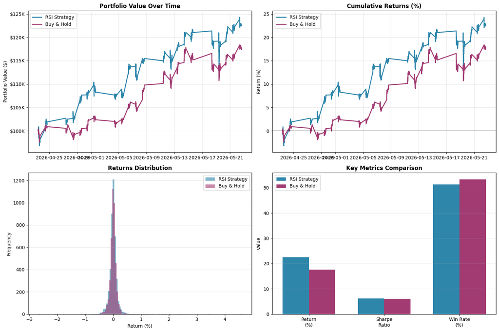

```
Exporting results...

======================================================================
BACKTEST COMPLETE!
======================================================================
```

```python
import yfinance as yf
import pandas as pd
import numpy as np
from ta.momentum import RSIIndicator
import matplotlib.pyplot as plt
import warnings

warnings.filterwarnings('ignore')

# ============================================================================
#                               CONFIGURATION
# ============================================================================

CONFIG = {
    'tickers': ["SPY", "AAPL", "MSFT", "NVDA", "TSM", "AMD", "AVGO", "V", "RKLB", "TSEM"],
    'interval': "2m",
    'period': "1mo",
    'rsi_window': 14,
    'rsi_lower': 30,
    'rsi_upper': 70,
    'initial_capital': 100000,
    'transaction_cost': 0.001,  # 0.1% per trade

    # Trading hours configuration (US market: 6.5 hours/day, 252 days/year)
    'trading_hours_per_day': 6.5,
    'trading_days_per_year': 252,
}

# Calculate periods
INTERVAL_MINUTES = {
    '1m': 1, '2m': 2, '5m': 5, '15m': 15, '30m': 30,
    '60m': 60, '1h': 60, '90m': 90,
    '1d': 60 * 6.5,  # 1 day = 6.5 trading hours
    '5d': 60 * 6.5 * 5,
    '1wk': 60 * 6.5 * 5,
}

minutes_per_day = CONFIG['trading_hours_per_day'] * 60
interval_min = INTERVAL_MINUTES.get(CONFIG['interval'], 60)
bars_per_day = minutes_per_day / interval_min
CONFIG['periods_per_year'] = bars_per_day * CONFIG['trading_days_per_year']

print("="*70)
print("RSI INTRADAY BACKTESTING - PROFESSIONAL VERSION")
print("="*70)
print(f"Tickers: {CONFIG['tickers']}")
print(f"Interval: {CONFIG['interval']} | Period: {CONFIG['period']}")
print(f"RSI({CONFIG['rsi_window']}): {CONFIG['rsi_lower']}/{CONFIG['rsi_upper']}")
print(f"Initial Capital: ${CONFIG['initial_capital']:,}")
print(f"Trading hours/day: {CONFIG['trading_hours_per_day']}")
print(f"Bars per day: {bars_per_day:.1f}")
print(f"Periods per year: {CONFIG['periods_per_year']:.0f}")
print("="*70 + "\n")

TICKERS = CONFIG['tickers'].copy()

# ============================================================================
#                DOWNLOAD DATA - WITH ERROR HANDLING
# ============================================================================

print("Downloading data...")

data = {}
failed_tickers = []

for ticker in TICKERS:
    try:
        df = yf.download(ticker, interval=CONFIG['interval'], period=CONFIG['period'], progress=False)

        if df.empty:
            print(f"     {ticker}: No data available")
            failed_tickers.append(ticker)
            continue

        df = df[['Close']].dropna()
        df.columns = [ticker]
        df = df[~df.index.duplicated(keep='first')]

        data[ticker] = df
        print(f"   {ticker}: {len(df)} candles downloaded")

    except Exception as e:
        print(f"   {ticker}: Error - {str(e)}")
        failed_tickers.append(ticker)

TICKERS = [t for t in TICKERS if t not in failed_tickers]

if not TICKERS:
    print("No data downloaded. Exiting.")
    exit()

print(f"\nSuccessfully downloaded {len(TICKERS)} tickers\n")

# ============================================================================
#                          PREPARE PRICE DATA
# ============================================================================

print("Preparing price data...")

prices = pd.concat(data.values(), axis=1).dropna()

print(f"   Data shape: {prices.shape}")
print(f"   Date range: {prices.index[0]} to {prices.index[-1]}")
print(f"   Total candles: {len(prices)}\n")

returns = prices.pct_change().fillna(0)

# ============================================================================
#                            CALCULATE RSI
# ============================================================================

print("Calculating RSI...")

rsi = pd.DataFrame(index=prices.index)

for ticker in TICKERS:
    try:
        rsi[ticker] = RSIIndicator(
            close=prices[ticker],
            window=CONFIG['rsi_window']
        ).rsi()
        print(f"    {ticker}: RSI calculated")
    except Exception as e:
        print(f"    {ticker}: RSI calculation failed - {str(e)}")

print()

# ============================================================================
#                           GENERATE SIGNALS
# ============================================================================

print("Generating trading signals...")

signals = pd.DataFrame(0, index=prices.index, columns=TICKERS)

for ticker in TICKERS:
    buy_signal = rsi[ticker] < CONFIG['rsi_lower']
    sell_signal = rsi[ticker] > CONFIG['rsi_upper']

    #Use NaN for "no change" so ffill works correctly
    signal = pd.Series(np.nan, index=prices.index, dtype=float)
    signal[buy_signal] = 1     # BUY
    signal[sell_signal] = 0    # SELL
    signal = signal.ffill().fillna(0)  # Hold previous state, default to 0

    signals[ticker] = signal

    n_buy_triggers = buy_signal.sum()
    n_sell_triggers = sell_signal.sum()
    pct_in_position = (signal == 1).sum() / len(signal) * 100

    print(f"   {ticker}: {n_buy_triggers} buy triggers, {n_sell_triggers} sell triggers, {pct_in_position:.1f}% in position")

print()

# ============================================================================
#                        BACKTEST RSI STRATEGY
# ============================================================================

print("RSI Strategy Backtest...")

active = signals.copy()
active_sum = active.sum(axis=1).replace(0, np.nan)
weights = active.div(active_sum, axis=0).fillna(0)

portfolio_returns = (weights.shift(1) * returns).sum(axis=1)
portfolio_returns = portfolio_returns.fillna(0)

position_changes = active.diff().abs().sum(axis=1)
transaction_costs = position_changes * CONFIG['transaction_cost'] / len(TICKERS)

net_returns = portfolio_returns - transaction_costs
equity_rsi = (1 + net_returns).cumprod() * CONFIG['initial_capital']

print(f"   Final Value: ${equity_rsi.iloc[-1]:,.2f}")
print(f"   Total Return: {(equity_rsi.iloc[-1] / CONFIG['initial_capital'] - 1) * 100:.2f}%\n")

# ============================================================================
#                                BUY & HOLD
# ============================================================================

print("Buy & Hold Backtest...")

bh_weights = pd.DataFrame(1/len(TICKERS), index=returns.index, columns=TICKERS)
bh_returns = (bh_weights * returns).sum(axis=1)
equity_bh = (1 + bh_returns).cumprod() * CONFIG['initial_capital']

print(f"   Final Value: ${equity_bh.iloc[-1]:,.2f}")
print(f"   Total Return: {(equity_bh.iloc[-1] / CONFIG['initial_capital'] - 1) * 100:.2f}%\n")

# ============================================================================
#                CALCULATE METRICS - PROFESSIONAL ANNUALIZATION
# ============================================================================

print("="*70)
print("PERFORMANCE METRICS")
print("="*70)

def calculate_metrics(equity_curve, returns, initial_capital, periods_per_year):
    """Calculate comprehensive metrics with configurable annualization"""

    ppy = periods_per_year  # Periods per year (configurable)

    total_return = (equity_curve.iloc[-1] / initial_capital - 1)

    # CAGR using actual periods
    years = len(equity_curve) / ppy
    cagr = (equity_curve.iloc[-1] / initial_capital) ** (1/years) - 1 if years > 0 else 0

    # Volatility (annualized using ppy)
    volatility = returns.std() * np.sqrt(ppy)

    # Sharpe Ratio (annualized using ppy)
    sharpe = (returns.mean() / returns.std()) * np.sqrt(ppy) if returns.std() > 0 else 0

    # Max Drawdown
    peak = equity_curve.cummax()
    drawdown = (equity_curve - peak) / peak
    max_dd = drawdown.min()

    # Win Rate
    win_rate = (returns > 0).sum() / len(returns)

    return {
        'Total Return': total_return,
        'CAGR': cagr,
        'Volatility': volatility,
        'Sharpe Ratio': sharpe,
        'Max Drawdown': max_dd,
        'Win Rate': win_rate,
        'Final Value': equity_curve.iloc[-1]
    }

ppy = CONFIG['periods_per_year']
metrics_rsi = calculate_metrics(equity_rsi, net_returns, CONFIG['initial_capital'], ppy)
metrics_bh = calculate_metrics(equity_bh, bh_returns, CONFIG['initial_capital'], ppy)

metrics_df = pd.DataFrame({
    'RSI Strategy': metrics_rsi,
    'Buy & Hold': metrics_bh
})

print("\n" + metrics_df.to_string())

print("\n" + "="*70)
print("COMPARISON")
print("="*70)

outperformance = metrics_rsi['Total Return'] - metrics_bh['Total Return']
sharpe_diff = metrics_rsi['Sharpe Ratio'] - metrics_bh['Sharpe Ratio']

print(f"Return Difference: {outperformance*100:+.2f}%")
print(f"Sharpe Difference: {sharpe_diff:+.3f}")

if metrics_rsi['Sharpe Ratio'] > metrics_bh['Sharpe Ratio']:
    print(f"RSI has better risk-adjusted returns")
else:
    print(f"Buy & Hold has better risk-adjusted returns")

print("="*70 + "\n")

# ============================================================================
#                               VISUALIZATION
# ============================================================================

print("Creating visualizations...")

fig, axes = plt.subplots(2, 2, figsize=(15, 10))

# Plot 1: Equity curves
ax = axes[0, 0]
ax.plot(equity_rsi.index, equity_rsi.values, label='RSI Strategy', linewidth=2, color='#2E86AB')
ax.plot(equity_bh.index, equity_bh.values, label='Buy & Hold', linewidth=2, color='#A23B72')
ax.set_title('Portfolio Value Over Time', fontweight='bold', fontsize=12)
ax.set_ylabel('Portfolio Value ($)')
ax.legend()
ax.grid(True, alpha=0.3)
ax.yaxis.set_major_formatter(plt.FuncFormatter(lambda x, p: f'${x/1000:.0f}K'))

# Plot 2: Cumulative returns
ax = axes[0, 1]
cum_ret_rsi = (equity_rsi / CONFIG['initial_capital'] - 1) * 100
cum_ret_bh = (equity_bh / CONFIG['initial_capital'] - 1) * 100
ax.plot(cum_ret_rsi.index, cum_ret_rsi.values, label='RSI Strategy', linewidth=2, color='#2E86AB')
ax.plot(cum_ret_bh.index, cum_ret_bh.values, label='Buy & Hold', linewidth=2, color='#A23B72')
ax.set_title('Cumulative Returns (%)', fontweight='bold', fontsize=12)
ax.set_ylabel('Return (%)')
ax.legend()
ax.grid(True, alpha=0.3)
ax.axhline(y=0, color='black', linestyle='-', alpha=0.3)

# Plot 3: Returns distribution
ax = axes[1, 0]
ax.hist(net_returns.dropna() * 100, bins=100, alpha=0.6, label='RSI Strategy', color='#2E86AB')
ax.hist(bh_returns.dropna() * 100, bins=100, alpha=0.6, label='Buy & Hold', color='#A23B72')
ax.set_title('Returns Distribution', fontweight='bold', fontsize=12)
ax.set_xlabel('Return (%)')
ax.set_ylabel('Frequency')
ax.legend()
ax.grid(True, alpha=0.3, axis='y')

# Plot 4: Metrics
ax = axes[1, 1]
metric_names = ['Return\n(%)', 'Sharpe\nRatio', 'Win Rate\n(%)']
rsi_vals = [metrics_rsi['Total Return']*100, metrics_rsi['Sharpe Ratio'], metrics_rsi['Win Rate']*100]
bh_vals = [metrics_bh['Total Return']*100, metrics_bh['Sharpe Ratio'], metrics_bh['Win Rate']*100]

x = np.arange(len(metric_names))
width = 0.35

ax.bar(x - width/2, rsi_vals, width, label='RSI Strategy', color='#2E86AB')
ax.bar(x + width/2, bh_vals, width, label='Buy & Hold', color='#A23B72')
ax.set_ylabel('Value')
ax.set_title('Key Metrics Comparison', fontweight='bold', fontsize=12)
ax.set_xticks(x)
ax.set_xticklabels(metric_names)
ax.legend()
ax.grid(True, alpha=0.3, axis='y')

plt.tight_layout()
plt.savefig('rsi_backtest.png', dpi=150, bbox_inches='tight')
print("Chart saved: rsi_backtest.png")
plt.show()

# ============================================================================
#                            EXPORT RESULTS
# ============================================================================

print("\nExporting results...")

results_df = pd.DataFrame({
    'Date': equity_rsi.index,
    'RSI_Strategy': equity_rsi.values,
    'BuyHold': equity_bh.values,
    'RSI_Values': rsi.mean(axis=1),
    'Returns': net_returns.values
})

results_df.to_csv('rsi_backtest_results2.csv', index=False)


metrics_df.to_csv('rsi_metrics2.csv')


print("\n" + "="*70)
print("BACKTEST COMPLETE!")
print("="*70)
```

## Experiment 2: Stricter thresholds (20/80)

Result: Performance drops, basically tied Hypothesis: Fewer trades = less opportunity

```
======================================================================
RSI INTRADAY BACKTESTING - PROFESSIONAL VERSION
======================================================================
Tickers: ['SPY', 'AAPL', 'MSFT', 'NVDA', 'TSM', 'AMD', 'AVGO', 'V', 'RKLB', 'TSEM']
Interval: 2m | Period: 1mo
RSI(14): 20/80
Initial Capital: $100,000
Trading hours/day: 6.5
Bars per day: 195.0
Periods per year: 49140
======================================================================

Downloading data...
   SPY: 4290 candles downloaded
   AAPL: 4290 candles downloaded
   MSFT: 4290 candles downloaded
   NVDA: 4290 candles downloaded
   TSM: 4290 candles downloaded
   AMD: 4290 candles downloaded
   AVGO: 4290 candles downloaded
   V: 4290 candles downloaded
   RKLB: 4290 candles downloaded
   TSEM: 4267 candles downloaded

Successfully downloaded 10 tickers

Preparing price data...
   Data shape: (4267, 10)
   Date range: 2026-04-23 09:30:00-04:00 to 2026-05-22 15:58:00-04:00
   Total candles: 4267

Calculating RSI...
    SPY: RSI calculated
    AAPL: RSI calculated
    MSFT: RSI calculated
    NVDA: RSI calculated
    TSM: RSI calculated
    AMD: RSI calculated
    AVGO: RSI calculated
    V: RSI calculated
```

[output cut: 31 more lines]

```
Sharpe Ratio       5.065991       6.047647
Max Drawdown      -0.050912      -0.060748
Win Rate           0.499648       0.532458
Final Value   117360.313127  117605.317434

======================================================================
COMPARISON
======================================================================
Return Difference: -0.25%
Sharpe Difference: -0.982
Buy & Hold has better risk-adjusted returns
======================================================================

Creating visualizations...
Chart saved: rsi_backtest.png
```

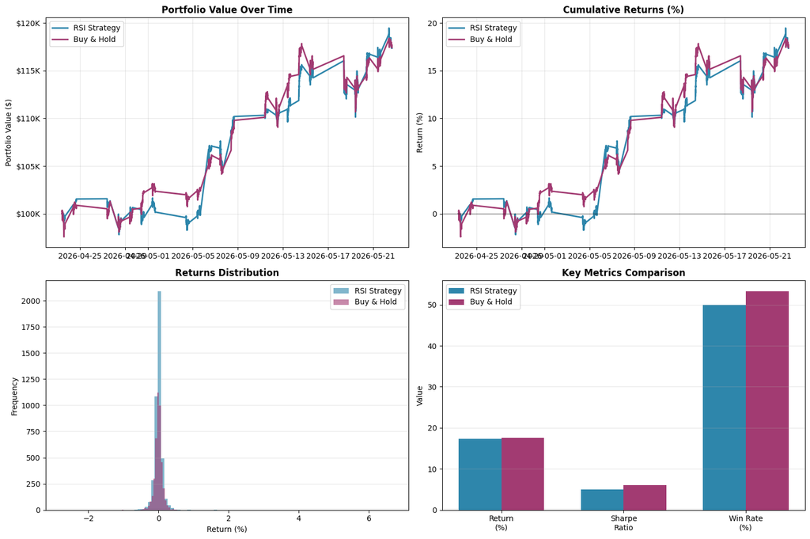

```
Exporting results...

======================================================================
BACKTEST COMPLETE!
======================================================================
```

```python
import yfinance as yf
import pandas as pd
import numpy as np
from ta.momentum import RSIIndicator
import matplotlib.pyplot as plt
import warnings

warnings.filterwarnings('ignore')

# ============================================================================
# CONFIGURATION
# ============================================================================

CONFIG = {
    'tickers': ["SPY", "AAPL", "MSFT", "NVDA", "TSM", "AMD", "AVGO", "V", "RKLB", "TSEM"],
    'interval': "2m",
    'period': "1mo",
    'rsi_window': 14,
    'rsi_lower': 20,
    'rsi_upper': 80,
    'initial_capital': 100000,
    'transaction_cost': 0.001,  # 0.1% per trade

    # Trading hours configuration (US market: 6.5 hours/day, 252 days/year)
    'trading_hours_per_day': 6.5,
    'trading_days_per_year': 252,
}

# Calculate periods per year based on interval
INTERVAL_MINUTES = {
    '1m': 1, '2m': 2, '5m': 5, '15m': 15, '30m': 30,
    '60m': 60, '1h': 60, '90m': 90,
    '1d': 60 * 6.5,  # 1 day = 6.5 trading hours
    '5d': 60 * 6.5 * 5,
    '1wk': 60 * 6.5 * 5,
}

minutes_per_day = CONFIG['trading_hours_per_day'] * 60
interval_min = INTERVAL_MINUTES.get(CONFIG['interval'], 60)
bars_per_day = minutes_per_day / interval_min
CONFIG['periods_per_year'] = bars_per_day * CONFIG['trading_days_per_year']

print("="*70)
print("RSI INTRADAY BACKTESTING - PROFESSIONAL VERSION")
print("="*70)
print(f"Tickers: {CONFIG['tickers']}")
print(f"Interval: {CONFIG['interval']} | Period: {CONFIG['period']}")
print(f"RSI({CONFIG['rsi_window']}): {CONFIG['rsi_lower']}/{CONFIG['rsi_upper']}")
print(f"Initial Capital: ${CONFIG['initial_capital']:,}")
print(f"Trading hours/day: {CONFIG['trading_hours_per_day']}")
print(f"Bars per day: {bars_per_day:.1f}")
print(f"Periods per year: {CONFIG['periods_per_year']:.0f}")
print("="*70 + "\n")

TICKERS = CONFIG['tickers'].copy()

# ============================================================================
#                DOWNLOAD DATA - WITH ERROR HANDLING
# ============================================================================

print("Downloading data...")

data = {}
failed_tickers = []

for ticker in TICKERS:
    try:
        df = yf.download(ticker, interval=CONFIG['interval'], period=CONFIG['period'], progress=False)

        if df.empty:
            print(f"     {ticker}: No data available")
            failed_tickers.append(ticker)
            continue

        df = df[['Close']].dropna()
        df.columns = [ticker]
        df = df[~df.index.duplicated(keep='first')]

        data[ticker] = df
        print(f"   {ticker}: {len(df)} candles downloaded")

    except Exception as e:
        print(f"   {ticker}: Error - {str(e)}")
        failed_tickers.append(ticker)

TICKERS = [t for t in TICKERS if t not in failed_tickers]

if not TICKERS:
    print("No data downloaded. Exiting.")
    exit()

print(f"\nSuccessfully downloaded {len(TICKERS)} tickers\n")

# ============================================================================
#                        PREPARE PRICE DATA
# ============================================================================

print("Preparing price data...")

prices = pd.concat(data.values(), axis=1).dropna()

print(f"   Data shape: {prices.shape}")
print(f"   Date range: {prices.index[0]} to {prices.index[-1]}")
print(f"   Total candles: {len(prices)}\n")

returns = prices.pct_change().fillna(0)

# ============================================================================
#                               CALCULATE RSI
# ============================================================================

print("Calculating RSI...")

rsi = pd.DataFrame(index=prices.index)

for ticker in TICKERS:
    try:
        rsi[ticker] = RSIIndicator(
            close=prices[ticker],
            window=CONFIG['rsi_window']
        ).rsi()
        print(f"    {ticker}: RSI calculated")
    except Exception as e:
        print(f"    {ticker}: RSI calculation failed - {str(e)}")

print()

# ============================================================================
#                            GENERATE SIGNALS
# ============================================================================

print("Generating trading signals...")

signals = pd.DataFrame(0, index=prices.index, columns=TICKERS)

for ticker in TICKERS:
    buy_signal = rsi[ticker] < CONFIG['rsi_lower']
    sell_signal = rsi[ticker] > CONFIG['rsi_upper']

    # FIX: Use NaN for "no change" so ffill works correctly
    signal = pd.Series(np.nan, index=prices.index, dtype=float)
    signal[buy_signal] = 1     # BUY (enter position)
    signal[sell_signal] = 0    # SELL (exit position)
    signal = signal.ffill().fillna(0)  # Hold previous state, default to 0

    signals[ticker] = signal

    n_buy_triggers = buy_signal.sum()
    n_sell_triggers = sell_signal.sum()
    pct_in_position = (signal == 1).sum() / len(signal) * 100

    print(f"   {ticker}: {n_buy_triggers} buy triggers, {n_sell_triggers} sell triggers, {pct_in_position:.1f}% in position")

print()

# ============================================================================
#                            BACKTEST RSI STRATEGY
# ============================================================================

print("RSI Strategy Backtest...")

active = signals.copy()
active_sum = active.sum(axis=1).replace(0, np.nan)
weights = active.div(active_sum, axis=0).fillna(0)

portfolio_returns = (weights.shift(1) * returns).sum(axis=1)
portfolio_returns = portfolio_returns.fillna(0)

position_changes = active.diff().abs().sum(axis=1)
transaction_costs = position_changes * CONFIG['transaction_cost'] / len(TICKERS)

net_returns = portfolio_returns - transaction_costs
equity_rsi = (1 + net_returns).cumprod() * CONFIG['initial_capital']

print(f"   Final Value: ${equity_rsi.iloc[-1]:,.2f}")
print(f"   Total Return: {(equity_rsi.iloc[-1] / CONFIG['initial_capital'] - 1) * 100:.2f}%\n")

# ============================================================================
#                        BACKTEST BUY & HOLD
# ============================================================================

print("Buy & Hold Backtest...")

bh_weights = pd.DataFrame(1/len(TICKERS), index=returns.index, columns=TICKERS)
bh_returns = (bh_weights * returns).sum(axis=1)
equity_bh = (1 + bh_returns).cumprod() * CONFIG['initial_capital']

print(f"   Final Value: ${equity_bh.iloc[-1]:,.2f}")
print(f"   Total Return: {(equity_bh.iloc[-1] / CONFIG['initial_capital'] - 1) * 100:.2f}%\n")

# ============================================================================
#                CALCULATE METRICS - PROFESSIONAL ANNUALIZATION
# ============================================================================

print("="*70)
print("PERFORMANCE METRICS")
print("="*70)

def calculate_metrics(equity_curve, returns, initial_capital, periods_per_year):
    """Calculate comprehensive metrics with configurable annualization"""

    ppy = periods_per_year  # Periods per year (configurable)

    total_return = (equity_curve.iloc[-1] / initial_capital - 1)

    # CAGR using actual periods
    years = len(equity_curve) / ppy
    cagr = (equity_curve.iloc[-1] / initial_capital) ** (1/years) - 1 if years > 0 else 0

    # Volatility (annualized using ppy)
    volatility = returns.std() * np.sqrt(ppy)

    # Sharpe Ratio (annualized using ppy)
    sharpe = (returns.mean() / returns.std()) * np.sqrt(ppy) if returns.std() > 0 else 0

    # Max Drawdown
    peak = equity_curve.cummax()
    drawdown = (equity_curve - peak) / peak
    max_dd = drawdown.min()

    # Win Rate
    win_rate = (returns > 0).sum() / len(returns)

    return {
        'Total Return': total_return,
        'CAGR': cagr,
        'Volatility': volatility,
        'Sharpe Ratio': sharpe,
        'Max Drawdown': max_dd,
        'Win Rate': win_rate,
        'Final Value': equity_curve.iloc[-1]
    }

ppy = CONFIG['periods_per_year']
metrics_rsi = calculate_metrics(equity_rsi, net_returns, CONFIG['initial_capital'], ppy)
metrics_bh = calculate_metrics(equity_bh, bh_returns, CONFIG['initial_capital'], ppy)

metrics_df = pd.DataFrame({
    'RSI Strategy': metrics_rsi,
    'Buy & Hold': metrics_bh
})

print("\n" + metrics_df.to_string())

print("\n" + "="*70)
print("COMPARISON")
print("="*70)

outperformance = metrics_rsi['Total Return'] - metrics_bh['Total Return']
sharpe_diff = metrics_rsi['Sharpe Ratio'] - metrics_bh['Sharpe Ratio']

print(f"Return Difference: {outperformance*100:+.2f}%")
print(f"Sharpe Difference: {sharpe_diff:+.3f}")

if metrics_rsi['Sharpe Ratio'] > metrics_bh['Sharpe Ratio']:
    print(f"RSI has better risk-adjusted returns")
else:
    print(f"Buy & Hold has better risk-adjusted returns")

print("="*70 + "\n")

# ============================================================================
#                                  VISUALIZATION
# ============================================================================

print("Creating visualizations...")

fig, axes = plt.subplots(2, 2, figsize=(15, 10))

# Plot 1: Equity curves
ax = axes[0, 0]
ax.plot(equity_rsi.index, equity_rsi.values, label='RSI Strategy', linewidth=2, color='#2E86AB')
ax.plot(equity_bh.index, equity_bh.values, label='Buy & Hold', linewidth=2, color='#A23B72')
ax.set_title('Portfolio Value Over Time', fontweight='bold', fontsize=12)
ax.set_ylabel('Portfolio Value ($)')
ax.legend()
ax.grid(True, alpha=0.3)
ax.yaxis.set_major_formatter(plt.FuncFormatter(lambda x, p: f'${x/1000:.0f}K'))

# Plot 2: Cumulative returns
ax = axes[0, 1]
cum_ret_rsi = (equity_rsi / CONFIG['initial_capital'] - 1) * 100
cum_ret_bh = (equity_bh / CONFIG['initial_capital'] - 1) * 100
ax.plot(cum_ret_rsi.index, cum_ret_rsi.values, label='RSI Strategy', linewidth=2, color='#2E86AB')
ax.plot(cum_ret_bh.index, cum_ret_bh.values, label='Buy & Hold', linewidth=2, color='#A23B72')
ax.set_title('Cumulative Returns (%)', fontweight='bold', fontsize=12)
ax.set_ylabel('Return (%)')
ax.legend()
ax.grid(True, alpha=0.3)
ax.axhline(y=0, color='black', linestyle='-', alpha=0.3)

# Plot 3: Returns distribution
ax = axes[1, 0]
ax.hist(net_returns.dropna() * 100, bins=100, alpha=0.6, label='RSI Strategy', color='#2E86AB')
ax.hist(bh_returns.dropna() * 100, bins=100, alpha=0.6, label='Buy & Hold', color='#A23B72')
ax.set_title('Returns Distribution', fontweight='bold', fontsize=12)
ax.set_xlabel('Return (%)')
ax.set_ylabel('Frequency')
ax.legend()
ax.grid(True, alpha=0.3, axis='y')

# Plot 4: Metrics
ax = axes[1, 1]
metric_names = ['Return\n(%)', 'Sharpe\nRatio', 'Win Rate\n(%)']
rsi_vals = [metrics_rsi['Total Return']*100, metrics_rsi['Sharpe Ratio'], metrics_rsi['Win Rate']*100]
bh_vals = [metrics_bh['Total Return']*100, metrics_bh['Sharpe Ratio'], metrics_bh['Win Rate']*100]

x = np.arange(len(metric_names))
width = 0.35

ax.bar(x - width/2, rsi_vals, width, label='RSI Strategy', color='#2E86AB')
ax.bar(x + width/2, bh_vals, width, label='Buy & Hold', color='#A23B72')
ax.set_ylabel('Value')
ax.set_title('Key Metrics Comparison', fontweight='bold', fontsize=12)
ax.set_xticks(x)
ax.set_xticklabels(metric_names)
ax.legend()
ax.grid(True, alpha=0.3, axis='y')

plt.tight_layout()
plt.savefig('rsi_backtest.png', dpi=150, bbox_inches='tight')
print("Chart saved: rsi_backtest.png")
plt.show()

# ============================================================================
#                                EXPORT RESULTS
# ============================================================================

print("\nExporting results...")

results_df = pd.DataFrame({
    'Date': equity_rsi.index,
    'RSI_Strategy': equity_rsi.values,
    'BuyHold': equity_bh.values,
    'RSI_Values': rsi.mean(axis=1),
    'Returns': net_returns.values
})

results_df.to_csv('rsi_backtest_results3.csv', index=False)


metrics_df.to_csv('rsi_metrics3.csv')


print("\n" + "="*70)
print("BACKTEST COMPLETE!")
print("="*70)
```

## Experiment 3: Longer period (60 days)

Result: B&H wins by 9% Insight: RSI advantage was period-specific

```
======================================================================
RSI INTRADAY BACKTESTING - PROFESSIONAL VERSION
======================================================================
Tickers: ['SPY', 'AAPL', 'MSFT', 'NVDA', 'TSM', 'AMD', 'AVGO', 'V', 'RKLB', 'TSEM']
Interval: 2m | Period: 60d
RSI(14): 20/80
Initial Capital: $100,000
Trading hours/day: 6.5
Bars per day: 195.0
Periods per year: 49140
======================================================================

Downloading data...
   SPY: 5850 candles downloaded
   AAPL: 5850 candles downloaded
   MSFT: 5850 candles downloaded
   NVDA: 5850 candles downloaded
   TSM: 5850 candles downloaded
   AMD: 5850 candles downloaded
   AVGO: 5850 candles downloaded
   V: 5850 candles downloaded
   RKLB: 5850 candles downloaded
   TSEM: 5824 candles downloaded

Successfully downloaded 10 tickers

Preparing price data...
   Data shape: (5824, 10)
   Date range: 2026-04-13 09:30:00-04:00 to 2026-05-22 15:58:00-04:00
   Total candles: 5824

Calculating RSI...
    SPY: RSI calculated
    AAPL: RSI calculated
    MSFT: RSI calculated
    NVDA: RSI calculated
    TSM: RSI calculated
    AMD: RSI calculated
    AVGO: RSI calculated
    V: RSI calculated
```

[output cut: 31 more lines]

```
Sharpe Ratio       4.852544       7.707435
Max Drawdown      -0.050912      -0.060748
Win Rate           0.476648       0.535199
Final Value   121659.147267  130492.357024

======================================================================
COMPARISON
======================================================================
Return Difference: -8.83%
Sharpe Difference: -2.855
Buy & Hold has better risk-adjusted returns
======================================================================

Creating visualizations...
Chart saved: rsi_backtest.png
```

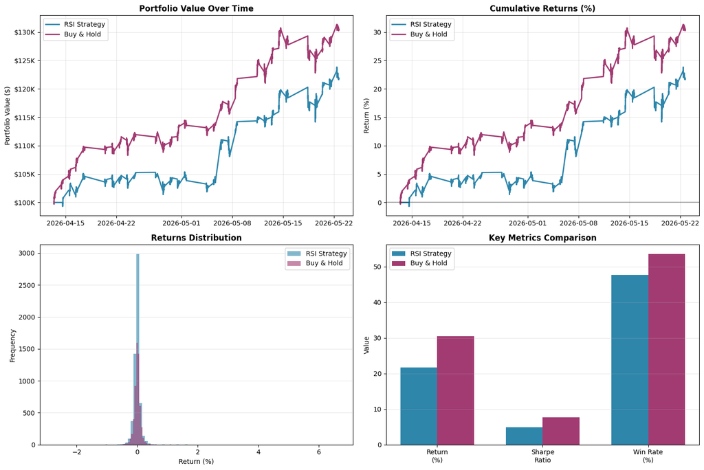

[output not shown]

```python
import yfinance as yf
import pandas as pd
import numpy as np
from ta.momentum import RSIIndicator
import matplotlib.pyplot as plt
import warnings

warnings.filterwarnings('ignore')

# ============================================================================
#                                  CONFIGURATION
# ============================================================================

CONFIG = {
    'tickers': ["SPY", "AAPL", "MSFT", "NVDA", "TSM", "AMD", "AVGO", "V", "RKLB", "TSEM"],
    'interval': "2m",
    'period': "60d",
    'rsi_window': 14,
    'rsi_lower': 20,
    'rsi_upper': 80,
    'initial_capital': 100000,
    'transaction_cost': 0.001,  # 0.1% per trade

    # Trading hours configuration (US market: 6.5 hours/day, 252 days/year)
    'trading_hours_per_day': 6.5,
    'trading_days_per_year': 252,
}

# Calculate periods per year based on interval
INTERVAL_MINUTES = {
    '1m': 1, '2m': 2, '5m': 5, '15m': 15, '30m': 30,
    '60m': 60, '1h': 60, '90m': 90,
    '1d': 60 * 6.5,  # 1 day = 6.5 trading hours
    '5d': 60 * 6.5 * 5,
    '1wk': 60 * 6.5 * 5,
}

minutes_per_day = CONFIG['trading_hours_per_day'] * 60
interval_min = INTERVAL_MINUTES.get(CONFIG['interval'], 60)
bars_per_day = minutes_per_day / interval_min
CONFIG['periods_per_year'] = bars_per_day * CONFIG['trading_days_per_year']

print("="*70)
print("RSI INTRADAY BACKTESTING - PROFESSIONAL VERSION")
print("="*70)
print(f"Tickers: {CONFIG['tickers']}")
print(f"Interval: {CONFIG['interval']} | Period: {CONFIG['period']}")
print(f"RSI({CONFIG['rsi_window']}): {CONFIG['rsi_lower']}/{CONFIG['rsi_upper']}")
print(f"Initial Capital: ${CONFIG['initial_capital']:,}")
print(f"Trading hours/day: {CONFIG['trading_hours_per_day']}")
print(f"Bars per day: {bars_per_day:.1f}")
print(f"Periods per year: {CONFIG['periods_per_year']:.0f}")
print("="*70 + "\n")

TICKERS = CONFIG['tickers'].copy()

# ============================================================================
#                    DOWNLOAD DATA - WITH ERROR HANDLING
# ============================================================================

print("Downloading data...")

data = {}
failed_tickers = []

for ticker in TICKERS:
    try:
        df = yf.download(ticker, interval=CONFIG['interval'], period=CONFIG['period'], progress=False)

        if df.empty:
            print(f"     {ticker}: No data available")
            failed_tickers.append(ticker)
            continue

        df = df[['Close']].dropna()
        df.columns = [ticker]
        df = df[~df.index.duplicated(keep='first')]

        data[ticker] = df
        print(f"   {ticker}: {len(df)} candles downloaded")

    except Exception as e:
        print(f"   {ticker}: Error - {str(e)}")
        failed_tickers.append(ticker)

TICKERS = [t for t in TICKERS if t not in failed_tickers]

if not TICKERS:
    print("No data downloaded. Exiting.")
    exit()

print(f"\nSuccessfully downloaded {len(TICKERS)} tickers\n")

# ============================================================================
#                            PREPARE PRICE DATA
# ============================================================================

print("Preparing price data...")

prices = pd.concat(data.values(), axis=1).dropna()

print(f"   Data shape: {prices.shape}")
print(f"   Date range: {prices.index[0]} to {prices.index[-1]}")
print(f"   Total candles: {len(prices)}\n")

returns = prices.pct_change().fillna(0)

# ============================================================================
#                                CALCULATE RSI
# ============================================================================

print("Calculating RSI...")

rsi = pd.DataFrame(index=prices.index)

for ticker in TICKERS:
    try:
        rsi[ticker] = RSIIndicator(
            close=prices[ticker],
            window=CONFIG['rsi_window']
        ).rsi()
        print(f"    {ticker}: RSI calculated")
    except Exception as e:
        print(f"    {ticker}: RSI calculation failed - {str(e)}")

print()

# ============================================================================
#                        GENERATE SIGNALS
# ============================================================================

print("Generating trading signals...")

signals = pd.DataFrame(0, index=prices.index, columns=TICKERS)

for ticker in TICKERS:
    buy_signal = rsi[ticker] < CONFIG['rsi_lower']
    sell_signal = rsi[ticker] > CONFIG['rsi_upper']

    # FIX: Use NaN for "no change" so ffill works correctly
    signal = pd.Series(np.nan, index=prices.index, dtype=float)
    signal[buy_signal] = 1     # BUY (enter position)
    signal[sell_signal] = 0    # SELL (exit position)
    signal = signal.ffill().fillna(0)  # Hold previous state, default to 0

    signals[ticker] = signal

    n_buy_triggers = buy_signal.sum()
    n_sell_triggers = sell_signal.sum()
    pct_in_position = (signal == 1).sum() / len(signal) * 100

    print(f"   {ticker}: {n_buy_triggers} buy triggers, {n_sell_triggers} sell triggers, {pct_in_position:.1f}% in position")

print()

# ============================================================================
#                        BACKTEST RSI STRATEGY
# ============================================================================

print("RSI Strategy Backtest...")

active = signals.copy()
active_sum = active.sum(axis=1).replace(0, np.nan)
weights = active.div(active_sum, axis=0).fillna(0)

portfolio_returns = (weights.shift(1) * returns).sum(axis=1)
portfolio_returns = portfolio_returns.fillna(0)

position_changes = active.diff().abs().sum(axis=1)
transaction_costs = position_changes * CONFIG['transaction_cost'] / len(TICKERS)

net_returns = portfolio_returns - transaction_costs
equity_rsi = (1 + net_returns).cumprod() * CONFIG['initial_capital']

print(f"   Final Value: ${equity_rsi.iloc[-1]:,.2f}")
print(f"   Total Return: {(equity_rsi.iloc[-1] / CONFIG['initial_capital'] - 1) * 100:.2f}%\n")

# ============================================================================
#                            BACKTEST BUY & HOLD
# ============================================================================

print("Buy & Hold Backtest...")

bh_weights = pd.DataFrame(1/len(TICKERS), index=returns.index, columns=TICKERS)
bh_returns = (bh_weights * returns).sum(axis=1)
equity_bh = (1 + bh_returns).cumprod() * CONFIG['initial_capital']

print(f"   Final Value: ${equity_bh.iloc[-1]:,.2f}")
print(f"   Total Return: {(equity_bh.iloc[-1] / CONFIG['initial_capital'] - 1) * 100:.2f}%\n")

# ============================================================================
#               CALCULATE METRICS - PROFESSIONAL ANNUALIZATION
# ============================================================================

print("="*70)
print("PERFORMANCE METRICS")
print("="*70)

def calculate_metrics(equity_curve, returns, initial_capital, periods_per_year):
    """Calculate comprehensive metrics with configurable annualization"""

    ppy = periods_per_year  # Periods per year (configurable)

    total_return = (equity_curve.iloc[-1] / initial_capital - 1)

    # CAGR using actual periods
    years = len(equity_curve) / ppy
    cagr = (equity_curve.iloc[-1] / initial_capital) ** (1/years) - 1 if years > 0 else 0

    # Volatility (annualized using ppy)
    volatility = returns.std() * np.sqrt(ppy)

    # Sharpe Ratio (annualized using ppy)
    sharpe = (returns.mean() / returns.std()) * np.sqrt(ppy) if returns.std() > 0 else 0

    # Max Drawdown
    peak = equity_curve.cummax()
    drawdown = (equity_curve - peak) / peak
    max_dd = drawdown.min()

    # Win Rate
    win_rate = (returns > 0).sum() / len(returns)

    return {
        'Total Return': total_return,
        'CAGR': cagr,
        'Volatility': volatility,
        'Sharpe Ratio': sharpe,
        'Max Drawdown': max_dd,
        'Win Rate': win_rate,
        'Final Value': equity_curve.iloc[-1]
    }

ppy = CONFIG['periods_per_year']
metrics_rsi = calculate_metrics(equity_rsi, net_returns, CONFIG['initial_capital'], ppy)
metrics_bh = calculate_metrics(equity_bh, bh_returns, CONFIG['initial_capital'], ppy)

metrics_df = pd.DataFrame({
    'RSI Strategy': metrics_rsi,
    'Buy & Hold': metrics_bh
})

print("\n" + metrics_df.to_string())

print("\n" + "="*70)
print("COMPARISON")
print("="*70)

outperformance = metrics_rsi['Total Return'] - metrics_bh['Total Return']
sharpe_diff = metrics_rsi['Sharpe Ratio'] - metrics_bh['Sharpe Ratio']

print(f"Return Difference: {outperformance*100:+.2f}%")
print(f"Sharpe Difference: {sharpe_diff:+.3f}")

if metrics_rsi['Sharpe Ratio'] > metrics_bh['Sharpe Ratio']:
    print(f"RSI has better risk-adjusted returns")
else:
    print(f"Buy & Hold has better risk-adjusted returns")

print("="*70 + "\n")

# ============================================================================
#                                VISUALIZATION
# ============================================================================

print("Creating visualizations...")

fig, axes = plt.subplots(2, 2, figsize=(15, 10))

# Plot 1: Equity curves
ax = axes[0, 0]
ax.plot(equity_rsi.index, equity_rsi.values, label='RSI Strategy', linewidth=2, color='#2E86AB')
ax.plot(equity_bh.index, equity_bh.values, label='Buy & Hold', linewidth=2, color='#A23B72')
ax.set_title('Portfolio Value Over Time', fontweight='bold', fontsize=12)
ax.set_ylabel('Portfolio Value ($)')
ax.legend()
ax.grid(True, alpha=0.3)
ax.yaxis.set_major_formatter(plt.FuncFormatter(lambda x, p: f'${x/1000:.0f}K'))

# Plot 2: Cumulative returns
ax = axes[0, 1]
cum_ret_rsi = (equity_rsi / CONFIG['initial_capital'] - 1) * 100
cum_ret_bh = (equity_bh / CONFIG['initial_capital'] - 1) * 100
ax.plot(cum_ret_rsi.index, cum_ret_rsi.values, label='RSI Strategy', linewidth=2, color='#2E86AB')
ax.plot(cum_ret_bh.index, cum_ret_bh.values, label='Buy & Hold', linewidth=2, color='#A23B72')
ax.set_title('Cumulative Returns (%)', fontweight='bold', fontsize=12)
ax.set_ylabel('Return (%)')
ax.legend()
ax.grid(True, alpha=0.3)
ax.axhline(y=0, color='black', linestyle='-', alpha=0.3)

# Plot 3: Returns distribution
ax = axes[1, 0]
ax.hist(net_returns.dropna() * 100, bins=100, alpha=0.6, label='RSI Strategy', color='#2E86AB')
ax.hist(bh_returns.dropna() * 100, bins=100, alpha=0.6, label='Buy & Hold', color='#A23B72')
ax.set_title('Returns Distribution', fontweight='bold', fontsize=12)
ax.set_xlabel('Return (%)')
ax.set_ylabel('Frequency')
ax.legend()
ax.grid(True, alpha=0.3, axis='y')

# Plot 4: Metrics
ax = axes[1, 1]
metric_names = ['Return\n(%)', 'Sharpe\nRatio', 'Win Rate\n(%)']
rsi_vals = [metrics_rsi['Total Return']*100, metrics_rsi['Sharpe Ratio'], metrics_rsi['Win Rate']*100]
bh_vals = [metrics_bh['Total Return']*100, metrics_bh['Sharpe Ratio'], metrics_bh['Win Rate']*100]

x = np.arange(len(metric_names))
width = 0.35

ax.bar(x - width/2, rsi_vals, width, label='RSI Strategy', color='#2E86AB')
ax.bar(x + width/2, bh_vals, width, label='Buy & Hold', color='#A23B72')
ax.set_ylabel('Value')
ax.set_title('Key Metrics Comparison', fontweight='bold', fontsize=12)
ax.set_xticks(x)
ax.set_xticklabels(metric_names)
ax.legend()
ax.grid(True, alpha=0.3, axis='y')

plt.tight_layout()
plt.savefig('rsi_backtest.png', dpi=150, bbox_inches='tight')
print("Chart saved: rsi_backtest.png")
plt.show()

# ============================================================================
# 9. EXPORT RESULTS
# ============================================================================

print("\nExporting results...")

results_df = pd.DataFrame({
    'Date': equity_rsi.index,
    'RSI_Strategy': equity_rsi.values,
    'BuyHold': equity_bh.values,
    'RSI_Values': rsi.mean(axis=1),
    'Returns': net_returns.values
})

results_df.to_csv('rsi_backtest_results4.csv', index=False)


metrics_df.to_csv('rsi_metrics4.csv')


print("\n" + "="*70)
print("BACKTEST COMPLETE!")
print("="*70)
```

## Experiment 4: Single asset (SPY only)

Result: RSI catastrophically underperforms (+1% vs +10%)

Insight: RSI strategy needed diversification

```
======================================================================
RSI INTRADAY BACKTESTING - PROFESSIONAL VERSION
======================================================================
Tickers: ['SPY']
Interval: 2m | Period: 60d
RSI(14): 20/80
Initial Capital: $100,000
Trading hours/day: 6.5
Bars per day: 195.0
Periods per year: 49140
======================================================================

Downloading data...
   SPY: 5850 candles downloaded

Successfully downloaded 1 tickers

Preparing price data...
   Data shape: (5850, 1)
   Date range: 2026-04-13 09:30:00-04:00 to 2026-05-22 15:58:00-04:00
   Total candles: 5850

Calculating RSI...
    SPY: RSI calculated

Generating trading signals...
   SPY: 30 buy triggers, 82 sell triggers, 38.6% in position

RSI Strategy Backtest...
   Final Value: $101,046.67
   Total Return: 1.05%

Buy & Hold Backtest...
   Final Value: $110,040.44
   Total Return: 10.04%

======================================================================
PERFORMANCE METRICS
======================================================================

               RSI Strategy     Buy & Hold
Total Return       0.010467       0.100404
CAGR               0.091402       1.233776
Volatility         0.068289       0.105982
Sharpe Ratio       1.314909       7.636352
Max Drawdown      -0.016406      -0.023596
Win Rate           0.199658       0.520684
Final Value   101046.671098  110040.443583

======================================================================
COMPARISON
======================================================================
Return Difference: -8.99%
Sharpe Difference: -6.321
Buy & Hold has better risk-adjusted returns
======================================================================

Creating visualizations...
Chart saved: rsi_backtest.png
```

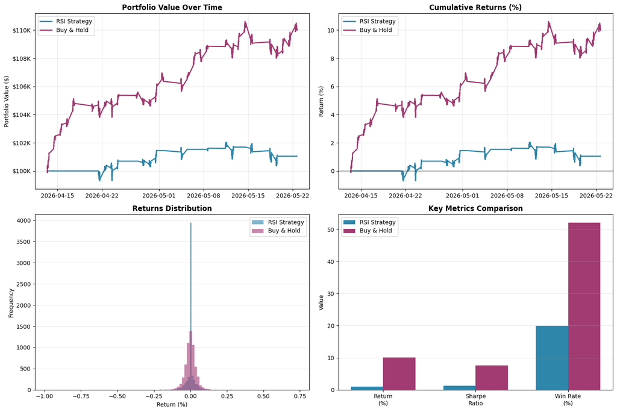

[output not shown]

```python
import yfinance as yf
import pandas as pd
import numpy as np
from ta.momentum import RSIIndicator
import matplotlib.pyplot as plt
import warnings

warnings.filterwarnings('ignore')

# ============================================================================
#                               CONFIGURATION
# ============================================================================

CONFIG = {
    'tickers': ["SPY"],
    'interval': "2m",
    'period': "60d",
    'rsi_window': 14,
    'rsi_lower': 20,
    'rsi_upper': 80,
    'initial_capital': 100000,
    'transaction_cost': 0.001,  # 0.1% per trade

    # Trading hours configuration (US market: 6.5 hours/day, 252 days/year)
    'trading_hours_per_day': 6.5,
    'trading_days_per_year': 252,
}

# Calculate periods per year based on interval
INTERVAL_MINUTES = {
    '1m': 1, '2m': 2, '5m': 5, '15m': 15, '30m': 30,
    '60m': 60, '1h': 60, '90m': 90,
    '1d': 60 * 6.5,  # 1 day = 6.5 trading hours
    '5d': 60 * 6.5 * 5,
    '1wk': 60 * 6.5 * 5,
}

minutes_per_day = CONFIG['trading_hours_per_day'] * 60
interval_min = INTERVAL_MINUTES.get(CONFIG['interval'], 60)
bars_per_day = minutes_per_day / interval_min
CONFIG['periods_per_year'] = bars_per_day * CONFIG['trading_days_per_year']

print("="*70)
print("RSI INTRADAY BACKTESTING - PROFESSIONAL VERSION")
print("="*70)
print(f"Tickers: {CONFIG['tickers']}")
print(f"Interval: {CONFIG['interval']} | Period: {CONFIG['period']}")
print(f"RSI({CONFIG['rsi_window']}): {CONFIG['rsi_lower']}/{CONFIG['rsi_upper']}")
print(f"Initial Capital: ${CONFIG['initial_capital']:,}")
print(f"Trading hours/day: {CONFIG['trading_hours_per_day']}")
print(f"Bars per day: {bars_per_day:.1f}")
print(f"Periods per year: {CONFIG['periods_per_year']:.0f}")
print("="*70 + "\n")

TICKERS = CONFIG['tickers'].copy()

# ============================================================================
#                    DOWNLOAD DATA - WITH ERROR HANDLING
# ============================================================================

print("Downloading data...")

data = {}
failed_tickers = []

for ticker in TICKERS:
    try:
        df = yf.download(ticker, interval=CONFIG['interval'], period=CONFIG['period'], progress=False)

        if df.empty:
            print(f"     {ticker}: No data available")
            failed_tickers.append(ticker)
            continue

        df = df[['Close']].dropna()
        df.columns = [ticker]
        df = df[~df.index.duplicated(keep='first')]

        data[ticker] = df
        print(f"   {ticker}: {len(df)} candles downloaded")

    except Exception as e:
        print(f"   {ticker}: Error - {str(e)}")
        failed_tickers.append(ticker)

TICKERS = [t for t in TICKERS if t not in failed_tickers]

if not TICKERS:
    print("No data downloaded. Exiting.")
    exit()

print(f"\nSuccessfully downloaded {len(TICKERS)} tickers\n")

# ============================================================================
#                            PREPARE PRICE DATA
# ============================================================================

print("Preparing price data...")

prices = pd.concat(data.values(), axis=1).dropna()

print(f"   Data shape: {prices.shape}")
print(f"   Date range: {prices.index[0]} to {prices.index[-1]}")
print(f"   Total candles: {len(prices)}\n")

returns = prices.pct_change().fillna(0)

# ============================================================================
#                                CALCULATE RSI
# ============================================================================

print("Calculating RSI...")

rsi = pd.DataFrame(index=prices.index)

for ticker in TICKERS:
    try:
        rsi[ticker] = RSIIndicator(
            close=prices[ticker],
            window=CONFIG['rsi_window']
        ).rsi()
        print(f"    {ticker}: RSI calculated")
    except Exception as e:
        print(f"    {ticker}: RSI calculation failed - {str(e)}")

print()

# ============================================================================
#                            GENERATE SIGNALS
# ============================================================================

print("Generating trading signals...")

signals = pd.DataFrame(0, index=prices.index, columns=TICKERS)

for ticker in TICKERS:
    buy_signal = rsi[ticker] < CONFIG['rsi_lower']
    sell_signal = rsi[ticker] > CONFIG['rsi_upper']

    # FIX: Use NaN for "no change" so ffill works correctly
    signal = pd.Series(np.nan, index=prices.index, dtype=float)
    signal[buy_signal] = 1     # BUY (enter position)
    signal[sell_signal] = 0    # SELL (exit position)
    signal = signal.ffill().fillna(0)  # Hold previous state, default to 0

    signals[ticker] = signal

    n_buy_triggers = buy_signal.sum()
    n_sell_triggers = sell_signal.sum()
    pct_in_position = (signal == 1).sum() / len(signal) * 100

    print(f"   {ticker}: {n_buy_triggers} buy triggers, {n_sell_triggers} sell triggers, {pct_in_position:.1f}% in position")

print()

# ============================================================================
#                        BACKTEST RSI STRATEGY
# ============================================================================

print("RSI Strategy Backtest...")

active = signals.copy()
active_sum = active.sum(axis=1).replace(0, np.nan)
weights = active.div(active_sum, axis=0).fillna(0)

portfolio_returns = (weights.shift(1) * returns).sum(axis=1)
portfolio_returns = portfolio_returns.fillna(0)

position_changes = active.diff().abs().sum(axis=1)
transaction_costs = position_changes * CONFIG['transaction_cost'] / len(TICKERS)

net_returns = portfolio_returns - transaction_costs
equity_rsi = (1 + net_returns).cumprod() * CONFIG['initial_capital']

print(f"   Final Value: ${equity_rsi.iloc[-1]:,.2f}")
print(f"   Total Return: {(equity_rsi.iloc[-1] / CONFIG['initial_capital'] - 1) * 100:.2f}%\n")

# ============================================================================
#                            BACKTEST BUY & HOLD
# ============================================================================

print("Buy & Hold Backtest...")

bh_weights = pd.DataFrame(1/len(TICKERS), index=returns.index, columns=TICKERS)
bh_returns = (bh_weights * returns).sum(axis=1)
equity_bh = (1 + bh_returns).cumprod() * CONFIG['initial_capital']

print(f"   Final Value: ${equity_bh.iloc[-1]:,.2f}")
print(f"   Total Return: {(equity_bh.iloc[-1] / CONFIG['initial_capital'] - 1) * 100:.2f}%\n")

# ============================================================================
#               CALCULATE METRICS - PROFESSIONAL ANNUALIZATION
# ============================================================================

print("="*70)
print("PERFORMANCE METRICS")
print("="*70)

def calculate_metrics(equity_curve, returns, initial_capital, periods_per_year):
    """Calculate comprehensive metrics with configurable annualization"""

    ppy = periods_per_year  # Periods per year (configurable)

    total_return = (equity_curve.iloc[-1] / initial_capital - 1)

    # CAGR using actual periods
    years = len(equity_curve) / ppy
    cagr = (equity_curve.iloc[-1] / initial_capital) ** (1/years) - 1 if years > 0 else 0

    # Volatility (annualized using ppy)
    volatility = returns.std() * np.sqrt(ppy)

    # Sharpe Ratio (annualized using ppy)
    sharpe = (returns.mean() / returns.std()) * np.sqrt(ppy) if returns.std() > 0 else 0

    # Max Drawdown
    peak = equity_curve.cummax()
    drawdown = (equity_curve - peak) / peak
    max_dd = drawdown.min()

    # Win Rate
    win_rate = (returns > 0).sum() / len(returns)

    return {
        'Total Return': total_return,
        'CAGR': cagr,
        'Volatility': volatility,
        'Sharpe Ratio': sharpe,
        'Max Drawdown': max_dd,
        'Win Rate': win_rate,
        'Final Value': equity_curve.iloc[-1]
    }

ppy = CONFIG['periods_per_year']
metrics_rsi = calculate_metrics(equity_rsi, net_returns, CONFIG['initial_capital'], ppy)
metrics_bh = calculate_metrics(equity_bh, bh_returns, CONFIG['initial_capital'], ppy)

metrics_df = pd.DataFrame({
    'RSI Strategy': metrics_rsi,
    'Buy & Hold': metrics_bh
})

print("\n" + metrics_df.to_string())

print("\n" + "="*70)
print("COMPARISON")
print("="*70)

outperformance = metrics_rsi['Total Return'] - metrics_bh['Total Return']
sharpe_diff = metrics_rsi['Sharpe Ratio'] - metrics_bh['Sharpe Ratio']

print(f"Return Difference: {outperformance*100:+.2f}%")
print(f"Sharpe Difference: {sharpe_diff:+.3f}")

if metrics_rsi['Sharpe Ratio'] > metrics_bh['Sharpe Ratio']:
    print(f"RSI has better risk-adjusted returns")
else:
    print(f"Buy & Hold has better risk-adjusted returns")

print("="*70 + "\n")

# ============================================================================
#                                VISUALIZATION
# ============================================================================

print("Creating visualizations...")

fig, axes = plt.subplots(2, 2, figsize=(15, 10))

# Plot 1: Equity curves
ax = axes[0, 0]
ax.plot(equity_rsi.index, equity_rsi.values, label='RSI Strategy', linewidth=2, color='#2E86AB')
ax.plot(equity_bh.index, equity_bh.values, label='Buy & Hold', linewidth=2, color='#A23B72')
ax.set_title('Portfolio Value Over Time', fontweight='bold', fontsize=12)
ax.set_ylabel('Portfolio Value ($)')
ax.legend()
ax.grid(True, alpha=0.3)
ax.yaxis.set_major_formatter(plt.FuncFormatter(lambda x, p: f'${x/1000:.0f}K'))

# Plot 2: Cumulative returns
ax = axes[0, 1]
cum_ret_rsi = (equity_rsi / CONFIG['initial_capital'] - 1) * 100
cum_ret_bh = (equity_bh / CONFIG['initial_capital'] - 1) * 100
ax.plot(cum_ret_rsi.index, cum_ret_rsi.values, label='RSI Strategy', linewidth=2, color='#2E86AB')
ax.plot(cum_ret_bh.index, cum_ret_bh.values, label='Buy & Hold', linewidth=2, color='#A23B72')
ax.set_title('Cumulative Returns (%)', fontweight='bold', fontsize=12)
ax.set_ylabel('Return (%)')
ax.legend()
ax.grid(True, alpha=0.3)
ax.axhline(y=0, color='black', linestyle='-', alpha=0.3)

# Plot 3: Returns distribution
ax = axes[1, 0]
ax.hist(net_returns.dropna() * 100, bins=100, alpha=0.6, label='RSI Strategy', color='#2E86AB')
ax.hist(bh_returns.dropna() * 100, bins=100, alpha=0.6, label='Buy & Hold', color='#A23B72')
ax.set_title('Returns Distribution', fontweight='bold', fontsize=12)
ax.set_xlabel('Return (%)')
ax.set_ylabel('Frequency')
ax.legend()
ax.grid(True, alpha=0.3, axis='y')

# Plot 4: Metrics
ax = axes[1, 1]
metric_names = ['Return\n(%)', 'Sharpe\nRatio', 'Win Rate\n(%)']
rsi_vals = [metrics_rsi['Total Return']*100, metrics_rsi['Sharpe Ratio'], metrics_rsi['Win Rate']*100]
bh_vals = [metrics_bh['Total Return']*100, metrics_bh['Sharpe Ratio'], metrics_bh['Win Rate']*100]

x = np.arange(len(metric_names))
width = 0.35

ax.bar(x - width/2, rsi_vals, width, label='RSI Strategy', color='#2E86AB')
ax.bar(x + width/2, bh_vals, width, label='Buy & Hold', color='#A23B72')
ax.set_ylabel('Value')
ax.set_title('Key Metrics Comparison', fontweight='bold', fontsize=12)
ax.set_xticks(x)
ax.set_xticklabels(metric_names)
ax.legend()
ax.grid(True, alpha=0.3, axis='y')

plt.tight_layout()
plt.savefig('rsi_backtest.png', dpi=150, bbox_inches='tight')
print("Chart saved: rsi_backtest.png")
plt.show()

# ============================================================================
#                                EXPORT RESULTS
# ============================================================================

print("\nExporting results...")

results_df = pd.DataFrame({
    'Date': equity_rsi.index,
    'RSI_Strategy': equity_rsi.values,
    'BuyHold': equity_bh.values,
    'RSI_Values': rsi.mean(axis=1),
    'Returns': net_returns.values
})

results_df.to_csv('rsi_backtest_results5.csv', index=False)


metrics_df.to_csv('rsi_metrics5.csv')


print("\n" + "="*70)
print("BACKTEST COMPLETE!")
print("="*70)
```

Result: Still B&H wins

Insight: More assets ≠ better strategy

```python
import yfinance as yf
import pandas as pd
import numpy as np
from ta.momentum import RSIIndicator
import matplotlib.pyplot as plt
import warnings

warnings.filterwarnings('ignore')

# ============================================================================
#                               CONFIGURATION
# ============================================================================

CONFIG = {
    'tickers': ["SPY","V","AMD","AAPL","MSFT","NVDA","AVGO","TSM","TSEM","RKLB","INTC","QCOM","ASML","GE","META","ADBE","QQQM","GOOGL","PLTR","ARM","SMCI","JPM","MS","CDNS","AMAT","BLK","TSLA","PFE","BMY","JNJ","LLY","UNH","ABBV","ISRG","NOC","RTX","LMT"],
    'interval': "2m",
    'period': "60d",
    'rsi_window': 14,
    'rsi_lower': 20,
    'rsi_upper': 80,
    'initial_capital': 100000,
    'transaction_cost': 0.001,  # 0.1% per trade

    # Trading hours configuration (US market: 6.5 hours/day, 252 days/year)
    'trading_hours_per_day': 6.5,
    'trading_days_per_year': 252,
}

# Calculate periods per year based on interval
INTERVAL_MINUTES = {
    '1m': 1, '2m': 2, '5m': 5, '15m': 15, '30m': 30,
    '60m': 60, '1h': 60, '90m': 90,
    '1d': 60 * 6.5,  # 1 day = 6.5 trading hours
    '5d': 60 * 6.5 * 5,
    '1wk': 60 * 6.5 * 5,
}

minutes_per_day = CONFIG['trading_hours_per_day'] * 60
interval_min = INTERVAL_MINUTES.get(CONFIG['interval'], 60)
bars_per_day = minutes_per_day / interval_min
CONFIG['periods_per_year'] = bars_per_day * CONFIG['trading_days_per_year']

print("="*70)
print("RSI INTRADAY BACKTESTING - PROFESSIONAL VERSION")
print("="*70)
print(f"Tickers: {CONFIG['tickers']}")
print(f"Interval: {CONFIG['interval']} | Period: {CONFIG['period']}")
print(f"RSI({CONFIG['rsi_window']}): {CONFIG['rsi_lower']}/{CONFIG['rsi_upper']}")
print(f"Initial Capital: ${CONFIG['initial_capital']:,}")
print(f"Trading hours/day: {CONFIG['trading_hours_per_day']}")
print(f"Bars per day: {bars_per_day:.1f}")
print(f"Periods per year: {CONFIG['periods_per_year']:.0f}")
print("="*70 + "\n")

TICKERS = CONFIG['tickers'].copy()

# ============================================================================
#                    DOWNLOAD DATA - WITH ERROR HANDLING
# ============================================================================

print("Downloading data...")

data = {}
failed_tickers = []

for ticker in TICKERS:
    try:
        df = yf.download(ticker, interval=CONFIG['interval'], period=CONFIG['period'], progress=False)

        if df.empty:
            print(f"     {ticker}: No data available")
            failed_tickers.append(ticker)
            continue

        df = df[['Close']].dropna()
        df.columns = [ticker]
        df = df[~df.index.duplicated(keep='first')]

        data[ticker] = df
        print(f"   {ticker}: {len(df)} candles downloaded")

    except Exception as e:
        print(f"   {ticker}: Error - {str(e)}")
        failed_tickers.append(ticker)

TICKERS = [t for t in TICKERS if t not in failed_tickers]

if not TICKERS:
    print("No data downloaded. Exiting.")
    exit()

print(f"\nSuccessfully downloaded {len(TICKERS)} tickers\n")

# ============================================================================
#                            PREPARE PRICE DATA
# ============================================================================

print("Preparing price data...")

prices = pd.concat(data.values(), axis=1).dropna()

print(f"   Data shape: {prices.shape}")
print(f"   Date range: {prices.index[0]} to {prices.index[-1]}")
print(f"   Total candles: {len(prices)}\n")

returns = prices.pct_change().fillna(0)

# ============================================================================
#                                CALCULATE RSI
# ============================================================================

print("Calculating RSI...")

rsi = pd.DataFrame(index=prices.index)

for ticker in TICKERS:
    try:
        rsi[ticker] = RSIIndicator(
            close=prices[ticker],
            window=CONFIG['rsi_window']
        ).rsi()
        print(f"    {ticker}: RSI calculated")
    except Exception as e:
        print(f"    {ticker}: RSI calculation failed - {str(e)}")

print()

# ============================================================================
#                              GENERATE SIGNALS
# ============================================================================

print("Generating trading signals...")

signals = pd.DataFrame(0, index=prices.index, columns=TICKERS)

for ticker in TICKERS:
    buy_signal = rsi[ticker] < CONFIG['rsi_lower']
    sell_signal = rsi[ticker] > CONFIG['rsi_upper']

    # FIX: Use NaN for "no change" so ffill works correctly
    signal = pd.Series(np.nan, index=prices.index, dtype=float)
    signal[buy_signal] = 1     # BUY (enter position)
    signal[sell_signal] = 0    # SELL (exit position)
    signal = signal.ffill().fillna(0)  # Hold previous state, default to 0

    signals[ticker] = signal

    n_buy_triggers = buy_signal.sum()
    n_sell_triggers = sell_signal.sum()
    pct_in_position = (signal == 1).sum() / len(signal) * 100

    print(f"   {ticker}: {n_buy_triggers} buy triggers, {n_sell_triggers} sell triggers, {pct_in_position:.1f}% in position")

print()

# ============================================================================
#                        BACKTEST RSI STRATEGY
# ============================================================================

print("RSI Strategy Backtest...")

active = signals.copy()
active_sum = active.sum(axis=1).replace(0, np.nan)
weights = active.div(active_sum, axis=0).fillna(0)

portfolio_returns = (weights.shift(1) * returns).sum(axis=1)
portfolio_returns = portfolio_returns.fillna(0)

position_changes = active.diff().abs().sum(axis=1)
transaction_costs = position_changes * CONFIG['transaction_cost'] / len(TICKERS)

net_returns = portfolio_returns - transaction_costs
equity_rsi = (1 + net_returns).cumprod() * CONFIG['initial_capital']

print(f"   Final Value: ${equity_rsi.iloc[-1]:,.2f}")
print(f"   Total Return: {(equity_rsi.iloc[-1] / CONFIG['initial_capital'] - 1) * 100:.2f}%\n")
```

[output not shown]

[output cut: 115 more lines]

```
Sharpe Ratio       4.048956       8.198605
Max Drawdown      -0.048363      -0.032757
Win Rate           0.507320       0.527884
Final Value   109631.026805  119377.189692

======================================================================
COMPARISON
======================================================================
Return Difference: -9.75%
Sharpe Difference: -4.150
Buy & Hold has better risk-adjusted returns
======================================================================

Creating visualizations...
Chart saved: rsi_backtest.png
```

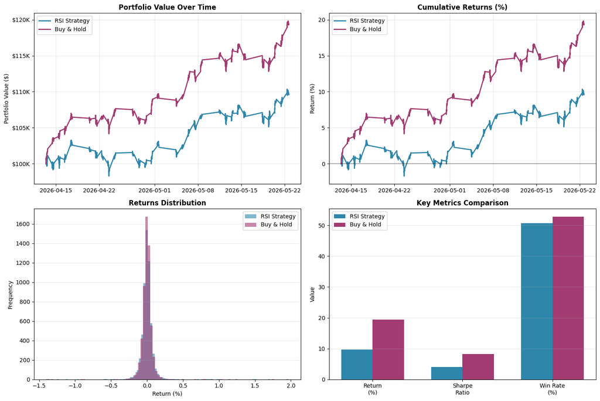

[output not shown]

```python
# ============================================================================
#                            BACKTEST BUY & HOLD
# ============================================================================

print("Buy & Hold Backtest...")

bh_weights = pd.DataFrame(1/len(TICKERS), index=returns.index, columns=TICKERS)
bh_returns = (bh_weights * returns).sum(axis=1)
equity_bh = (1 + bh_returns).cumprod() * CONFIG['initial_capital']

print(f"   Final Value: ${equity_bh.iloc[-1]:,.2f}")
print(f"   Total Return: {(equity_bh.iloc[-1] / CONFIG['initial_capital'] - 1) * 100:.2f}%\n")

# ============================================================================
#                  CALCULATE METRICS - PROFESSIONAL ANNUALIZATION
# ============================================================================

print("="*70)
print("PERFORMANCE METRICS")
print("="*70)

def calculate_metrics(equity_curve, returns, initial_capital, periods_per_year):
    """Calculate comprehensive metrics with configurable annualization"""

    ppy = periods_per_year  # Periods per year (configurable)

    total_return = (equity_curve.iloc[-1] / initial_capital - 1)

    # CAGR using actual periods
    years = len(equity_curve) / ppy
    cagr = (equity_curve.iloc[-1] / initial_capital) ** (1/years) - 1 if years > 0 else 0

    # Volatility (annualized using ppy)
    volatility = returns.std() * np.sqrt(ppy)

    # Sharpe Ratio (annualized using ppy)
    sharpe = (returns.mean() / returns.std()) * np.sqrt(ppy) if returns.std() > 0 else 0

    # Max Drawdown
    peak = equity_curve.cummax()
    drawdown = (equity_curve - peak) / peak
    max_dd = drawdown.min()

    # Win Rate
    win_rate = (returns > 0).sum() / len(returns)

    return {
        'Total Return': total_return,
        'CAGR': cagr,
        'Volatility': volatility,
        'Sharpe Ratio': sharpe,
        'Max Drawdown': max_dd,
        'Win Rate': win_rate,
        'Final Value': equity_curve.iloc[-1]
    }

ppy = CONFIG['periods_per_year']
metrics_rsi = calculate_metrics(equity_rsi, net_returns, CONFIG['initial_capital'], ppy)
metrics_bh = calculate_metrics(equity_bh, bh_returns, CONFIG['initial_capital'], ppy)

metrics_df = pd.DataFrame({
    'RSI Strategy': metrics_rsi,
    'Buy & Hold': metrics_bh
})

print("\n" + metrics_df.to_string())

print("\n" + "="*70)
print("COMPARISON")
print("="*70)

outperformance = metrics_rsi['Total Return'] - metrics_bh['Total Return']
sharpe_diff = metrics_rsi['Sharpe Ratio'] - metrics_bh['Sharpe Ratio']

print(f"Return Difference: {outperformance*100:+.2f}%")
print(f"Sharpe Difference: {sharpe_diff:+.3f}")

if metrics_rsi['Sharpe Ratio'] > metrics_bh['Sharpe Ratio']:
    print(f"RSI has better risk-adjusted returns")
else:
    print(f"Buy & Hold has better risk-adjusted returns")

print("="*70 + "\n")

# ============================================================================
#                                 VISUALIZATION
# ============================================================================

print("Creating visualizations...")

fig, axes = plt.subplots(2, 2, figsize=(15, 10))

# Plot 1: Equity curves
ax = axes[0, 0]
ax.plot(equity_rsi.index, equity_rsi.values, label='RSI Strategy', linewidth=2, color='#2E86AB')
ax.plot(equity_bh.index, equity_bh.values, label='Buy & Hold', linewidth=2, color='#A23B72')
ax.set_title('Portfolio Value Over Time', fontweight='bold', fontsize=12)
ax.set_ylabel('Portfolio Value ($)')
ax.legend()
ax.grid(True, alpha=0.3)
ax.yaxis.set_major_formatter(plt.FuncFormatter(lambda x, p: f'${x/1000:.0f}K'))

# Plot 2: Cumulative returns
ax = axes[0, 1]
cum_ret_rsi = (equity_rsi / CONFIG['initial_capital'] - 1) * 100
cum_ret_bh = (equity_bh / CONFIG['initial_capital'] - 1) * 100
ax.plot(cum_ret_rsi.index, cum_ret_rsi.values, label='RSI Strategy', linewidth=2, color='#2E86AB')
ax.plot(cum_ret_bh.index, cum_ret_bh.values, label='Buy & Hold', linewidth=2, color='#A23B72')
ax.set_title('Cumulative Returns (%)', fontweight='bold', fontsize=12)
ax.set_ylabel('Return (%)')
ax.legend()
ax.grid(True, alpha=0.3)
ax.axhline(y=0, color='black', linestyle='-', alpha=0.3)

# Plot 3: Returns distribution
ax = axes[1, 0]
ax.hist(net_returns.dropna() * 100, bins=100, alpha=0.6, label='RSI Strategy', color='#2E86AB')
ax.hist(bh_returns.dropna() * 100, bins=100, alpha=0.6, label='Buy & Hold', color='#A23B72')
ax.set_title('Returns Distribution', fontweight='bold', fontsize=12)
ax.set_xlabel('Return (%)')
ax.set_ylabel('Frequency')
ax.legend()
ax.grid(True, alpha=0.3, axis='y')

# Plot 4: Metrics
ax = axes[1, 1]
metric_names = ['Return\n(%)', 'Sharpe\nRatio', 'Win Rate\n(%)']
rsi_vals = [metrics_rsi['Total Return']*100, metrics_rsi['Sharpe Ratio'], metrics_rsi['Win Rate']*100]
bh_vals = [metrics_bh['Total Return']*100, metrics_bh['Sharpe Ratio'], metrics_bh['Win Rate']*100]

x = np.arange(len(metric_names))
width = 0.35

ax.bar(x - width/2, rsi_vals, width, label='RSI Strategy', color='#2E86AB')
ax.bar(x + width/2, bh_vals, width, label='Buy & Hold', color='#A23B72')
ax.set_ylabel('Value')
ax.set_title('Key Metrics Comparison', fontweight='bold', fontsize=12)
ax.set_xticks(x)
ax.set_xticklabels(metric_names)
ax.legend()
ax.grid(True, alpha=0.3, axis='y')

plt.tight_layout()
plt.savefig('rsi_backtest.png', dpi=150, bbox_inches='tight')
print("Chart saved: rsi_backtest.png")
plt.show()

# ============================================================================
#                            EXPORT RESULTS
# ============================================================================

print("\nExporting results...")

results_df = pd.DataFrame({
    'Date': equity_rsi.index,
    'RSI_Strategy': equity_rsi.values,
    'BuyHold': equity_bh.values,
    'RSI_Values': rsi.mean(axis=1),
    'Returns': net_returns.values
})

results_df.to_csv('rsi_backtest_results5.csv', index=False)


metrics_df.to_csv('rsi_metrics5.csv')


print("\n" + "="*70)
print("BACKTEST COMPLETE!")
print("="*70)
```

## Experiment 6: Long-term (2 years)

Result: B&H wins by 44%

```python
import yfinance as yf
import pandas as pd
import numpy as np
from ta.momentum import RSIIndicator
import matplotlib.pyplot as plt
import warnings

warnings.filterwarnings('ignore')

# ============================================================================
#                               CONFIGURATION
# ============================================================================

CONFIG = {
    'tickers': ["SPY","V","AMD","AAPL","MSFT","NVDA","AVGO","TSM","TSEM","RKLB","INTC","QCOM","ASML","GE","META","ADBE","QQQM","GOOGL","PLTR","ARM","SMCI","JPM","MS","CDNS","AMAT","BLK","TSLA","PFE","BMY","JNJ","LLY","UNH","ABBV","ISRG","NOC","RTX","LMT"],
    'interval': "1h",
    'period': "2y",
    'rsi_window': 14,
    'rsi_lower': 20,
    'rsi_upper': 80,
    'initial_capital': 100000,
    'transaction_cost': 0.001,  # 0.1% per trade

    # Trading hours configuration (US market: 6.5 hours/day, 252 days/year)
    'trading_hours_per_day': 6.5,
    'trading_days_per_year': 252,
}

# Calculate periods per year based on interval
INTERVAL_MINUTES = {
    '1m': 1, '2m': 2, '5m': 5, '15m': 15, '30m': 30,
    '60m': 60, '1h': 60, '90m': 90,
    '1d': 60 * 6.5,  # 1 day = 6.5 trading hours
    '5d': 60 * 6.5 * 5,
    '1wk': 60 * 6.5 * 5,
}

minutes_per_day = CONFIG['trading_hours_per_day'] * 60
interval_min = INTERVAL_MINUTES.get(CONFIG['interval'], 60)
bars_per_day = minutes_per_day / interval_min
CONFIG['periods_per_year'] = bars_per_day * CONFIG['trading_days_per_year']

print("="*70)
print("RSI INTRADAY BACKTESTING - PROFESSIONAL VERSION")
print("="*70)
print(f"Tickers: {CONFIG['tickers']}")
print(f"Interval: {CONFIG['interval']} | Period: {CONFIG['period']}")
print(f"RSI({CONFIG['rsi_window']}): {CONFIG['rsi_lower']}/{CONFIG['rsi_upper']}")
print(f"Initial Capital: ${CONFIG['initial_capital']:,}")
print(f"Trading hours/day: {CONFIG['trading_hours_per_day']}")
print(f"Bars per day: {bars_per_day:.1f}")
print(f"Periods per year: {CONFIG['periods_per_year']:.0f}")
print("="*70 + "\n")

TICKERS = CONFIG['tickers'].copy()

# ============================================================================
#                DOWNLOAD DATA - WITH ERROR HANDLING
# ============================================================================

print("Downloading data...")

data = {}
failed_tickers = []

for ticker in TICKERS:
    try:
        df = yf.download(ticker, interval=CONFIG['interval'], period=CONFIG['period'], progress=False)

        if df.empty:
            print(f"     {ticker}: No data available")
            failed_tickers.append(ticker)
            continue

        df = df[['Close']].dropna()
        df.columns = [ticker]
        df = df[~df.index.duplicated(keep='first')]

        data[ticker] = df
        print(f"   {ticker}: {len(df)} candles downloaded")

    except Exception as e:
        print(f"   {ticker}: Error - {str(e)}")
        failed_tickers.append(ticker)

TICKERS = [t for t in TICKERS if t not in failed_tickers]

if not TICKERS:
    print("No data downloaded. Exiting.")
    exit()

print(f"\nSuccessfully downloaded {len(TICKERS)} tickers\n")

# ============================================================================
#                            PREPARE PRICE DATA
# ============================================================================

print("Preparing price data...")

prices = pd.concat(data.values(), axis=1).dropna()

print(f"   Data shape: {prices.shape}")
print(f"   Date range: {prices.index[0]} to {prices.index[-1]}")
print(f"   Total candles: {len(prices)}\n")

returns = prices.pct_change().fillna(0)

# ============================================================================
#                                CALCULATE RSI
# ============================================================================

print("Calculating RSI...")

rsi = pd.DataFrame(index=prices.index)

for ticker in TICKERS:
    try:
        rsi[ticker] = RSIIndicator(
            close=prices[ticker],
            window=CONFIG['rsi_window']
        ).rsi()
        print(f"    {ticker}: RSI calculated")
    except Exception as e:
        print(f"    {ticker}: RSI calculation failed - {str(e)}")

print()

# ============================================================================
#                            GENERATE SIGNALS
# ============================================================================

print("Generating trading signals...")

signals = pd.DataFrame(0, index=prices.index, columns=TICKERS)

signals = pd.DataFrame(0, index=prices.index, columns=TICKERS)

for ticker in TICKERS:
    buy_signal = rsi[ticker] < CONFIG['rsi_lower']
    sell_signal = rsi[ticker] > CONFIG['rsi_upper']

    # FIX: Use NaN for "no change" so ffill works correctly
    signal = pd.Series(np.nan, index=prices.index, dtype=float)
    signal[buy_signal] = 1     # BUY (enter position)
    signal[sell_signal] = 0    # SELL (exit position)
    signal = signal.ffill().fillna(0)  # Hold previous state, default to 0

    signals[ticker] = signal

    n_buy_triggers = buy_signal.sum()
    n_sell_triggers = sell_signal.sum()
    pct_in_position = (signal == 1).sum() / len(signal) * 100

    print(f"   {ticker}: {n_buy_triggers} buy triggers, {n_sell_triggers} sell triggers, {pct_in_position:.1f}% in position")

print()

# ============================================================================
#                        BACKTEST RSI STRATEGY
# ============================================================================

print("RSI Strategy Backtest...")

active = signals.copy()
active_sum = active.sum(axis=1).replace(0, np.nan)
weights = active.div(active_sum, axis=0).fillna(0)

portfolio_returns = (weights.shift(1) * returns).sum(axis=1)
portfolio_returns = portfolio_returns.fillna(0)

position_changes = active.diff().abs().sum(axis=1)
transaction_costs = position_changes * CONFIG['transaction_cost'] / len(TICKERS)

net_returns = portfolio_returns - transaction_costs
equity_rsi = (1 + net_returns).cumprod() * CONFIG['initial_capital']
```

```python
print(f"   Final Value: ${equity_rsi.iloc[-1]:,.2f}")
print(f"   Total Return: {(equity_rsi.iloc[-1] / CONFIG['initial_capital'] - 1) * 100:.2f}%\n")

# ============================================================================
# 6. BACKTEST BUY & HOLD
# ============================================================================

print("Buy & Hold Backtest...")

bh_weights = pd.DataFrame(1/len(TICKERS), index=returns.index, columns=TICKERS)
bh_returns = (bh_weights * returns).sum(axis=1)
equity_bh = (1 + bh_returns).cumprod() * CONFIG['initial_capital']

print(f"   Final Value: ${equity_bh.iloc[-1]:,.2f}")
print(f"   Total Return: {(equity_bh.iloc[-1] / CONFIG['initial_capital'] - 1) * 100:.2f}%\n")

# ============================================================================
#               CALCULATE METRICS - PROFESSIONAL ANNUALIZATION
# ============================================================================

print("="*70)
print("PERFORMANCE METRICS")
print("="*70)

def calculate_metrics(equity_curve, returns, initial_capital, periods_per_year):
    """Calculate comprehensive metrics with configurable annualization"""

    ppy = periods_per_year  # Periods per year (configurable)

    total_return = (equity_curve.iloc[-1] / initial_capital - 1)

    # CAGR using actual periods
    years = len(equity_curve) / ppy
    cagr = (equity_curve.iloc[-1] / initial_capital) ** (1/years) - 1 if years > 0 else 0

    # Volatility (annualized using ppy)
    volatility = returns.std() * np.sqrt(ppy)

    # Sharpe Ratio (annualized using ppy)
    sharpe = (returns.mean() / returns.std()) * np.sqrt(ppy) if returns.std() > 0 else 0

    # Max Drawdown
    peak = equity_curve.cummax()
    drawdown = (equity_curve - peak) / peak
    max_dd = drawdown.min()

    # Win Rate
    win_rate = (returns > 0).sum() / len(returns)

    return {
        'Total Return': total_return,
        'CAGR': cagr,
        'Volatility': volatility,
        'Sharpe Ratio': sharpe,
        'Max Drawdown': max_dd,
        'Win Rate': win_rate,
        'Final Value': equity_curve.iloc[-1]
    }

ppy = CONFIG['periods_per_year']
metrics_rsi = calculate_metrics(equity_rsi, net_returns, CONFIG['initial_capital'], ppy)
metrics_bh = calculate_metrics(equity_bh, bh_returns, CONFIG['initial_capital'], ppy)

metrics_df = pd.DataFrame({
    'RSI Strategy': metrics_rsi,
    'Buy & Hold': metrics_bh
})

print("\n" + metrics_df.to_string())

print("\n" + "="*70)
print("COMPARISON")
print("="*70)

outperformance = metrics_rsi['Total Return'] - metrics_bh['Total Return']
sharpe_diff = metrics_rsi['Sharpe Ratio'] - metrics_bh['Sharpe Ratio']

print(f"Return Difference: {outperformance*100:+.2f}%")
print(f"Sharpe Difference: {sharpe_diff:+.3f}")

if metrics_rsi['Sharpe Ratio'] > metrics_bh['Sharpe Ratio']:
    print(f"RSI has better risk-adjusted returns")
else:
    print(f"Buy & Hold has better risk-adjusted returns")

print("="*70 + "\n")

# ============================================================================
#                                VISUALIZATION
# ============================================================================

print("Creating visualizations...")

fig, axes = plt.subplots(2, 2, figsize=(15, 10))

# Plot 1: Equity curves
ax = axes[0, 0]
ax.plot(equity_rsi.index, equity_rsi.values, label='RSI Strategy', linewidth=2, color='#2E86AB')
ax.plot(equity_bh.index, equity_bh.values, label='Buy & Hold', linewidth=2, color='#A23B72')
ax.set_title('Portfolio Value Over Time', fontweight='bold', fontsize=12)
ax.set_ylabel('Portfolio Value ($)')
ax.legend()
ax.grid(True, alpha=0.3)
ax.yaxis.set_major_formatter(plt.FuncFormatter(lambda x, p: f'${x/1000:.0f}K'))

# Plot 2: Cumulative returns
ax = axes[0, 1]
cum_ret_rsi = (equity_rsi / CONFIG['initial_capital'] - 1) * 100
cum_ret_bh = (equity_bh / CONFIG['initial_capital'] - 1) * 100
ax.plot(cum_ret_rsi.index, cum_ret_rsi.values, label='RSI Strategy', linewidth=2, color='#2E86AB')
ax.plot(cum_ret_bh.index, cum_ret_bh.values, label='Buy & Hold', linewidth=2, color='#A23B72')
ax.set_title('Cumulative Returns (%)', fontweight='bold', fontsize=12)
ax.set_ylabel('Return (%)')
ax.legend()
ax.grid(True, alpha=0.3)
ax.axhline(y=0, color='black', linestyle='-', alpha=0.3)

# Plot 3: Returns distribution
ax = axes[1, 0]
ax.hist(net_returns.dropna() * 100, bins=100, alpha=0.6, label='RSI Strategy', color='#2E86AB')
ax.hist(bh_returns.dropna() * 100, bins=100, alpha=0.6, label='Buy & Hold', color='#A23B72')
ax.set_title('Returns Distribution', fontweight='bold', fontsize=12)
ax.set_xlabel('Return (%)')
ax.set_ylabel('Frequency')
ax.legend()
ax.grid(True, alpha=0.3, axis='y')

# Plot 4: Metrics
ax = axes[1, 1]
metric_names = ['Return\n(%)', 'Sharpe\nRatio', 'Win Rate\n(%)']
rsi_vals = [metrics_rsi['Total Return']*100, metrics_rsi['Sharpe Ratio'], metrics_rsi['Win Rate']*100]
bh_vals = [metrics_bh['Total Return']*100, metrics_bh['Sharpe Ratio'], metrics_bh['Win Rate']*100]

x = np.arange(len(metric_names))
width = 0.35

ax.bar(x - width/2, rsi_vals, width, label='RSI Strategy', color='#2E86AB')
ax.bar(x + width/2, bh_vals, width, label='Buy & Hold', color='#A23B72')
ax.set_ylabel('Value')
ax.set_title('Key Metrics Comparison', fontweight='bold', fontsize=12)
ax.set_xticks(x)
ax.set_xticklabels(metric_names)
ax.legend()
ax.grid(True, alpha=0.3, axis='y')

plt.tight_layout()
plt.savefig('rsi_backtest.png', dpi=150, bbox_inches='tight')
print("Chart saved: rsi_backtest.png")
plt.show()

# ============================================================================
#                            EXPORT RESULTS
# ============================================================================

print("\nExporting results...")

results_df = pd.DataFrame({
    'Date': equity_rsi.index,
    'RSI_Strategy': equity_rsi.values,
    'BuyHold': equity_bh.values,
    'RSI_Values': rsi.mean(axis=1),
    'Returns': net_returns.values
})

results_df.to_csv('rsi_backtest_results6.csv', index=False)


metrics_df.to_csv('rsi_metrics6.csv')
```

[output not shown]

[output cut: 115 more lines]

```
Sharpe Ratio       1.055936       1.648236
Max Drawdown      -0.227165      -0.226761
Win Rate           0.521677       0.546655
Final Value   155386.966347  199340.179767

======================================================================
COMPARISON
======================================================================
Return Difference: -43.95%
Sharpe Difference: -0.592
Buy & Hold has better risk-adjusted returns
======================================================================

Creating visualizations...
Chart saved: rsi_backtest.png
```

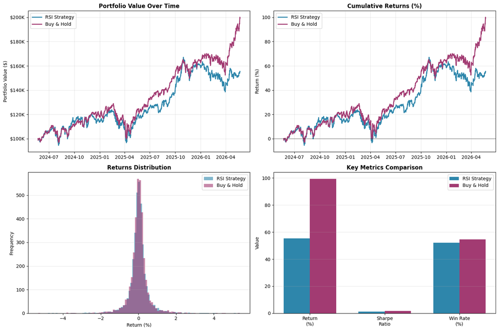

[output not shown]

```python
print("\n" + "="*70)
print("BACKTEST COMPLETE!")
print("="*70)
```

```python
import yfinance as yf
import pandas as pd
import numpy as np
from ta.momentum import RSIIndicator
import matplotlib.pyplot as plt
import warnings

warnings.filterwarnings('ignore')

# ============================================================================
#                               CONFIGURATION
# ============================================================================

CONFIG = {
    'tickers': ["SPY","V","AMD","AAPL","MSFT","NVDA","AVGO","TSM","TSEM","RKLB","INTC","QCOM","ASML","GE","META","ADBE","QQQM","GOOGL","PLTR","ARM","SMCI","JPM","MS","CDNS","AMAT","BLK","TSLA","PFE","BMY","JNJ","LLY","UNH","ABBV","ISRG","NOC","RTX","LMT"],
    'interval': "1h",
    'period': "2y",
    'rsi_window': 14,
    'rsi_lower': 30,
    'rsi_upper': 70,
    'initial_capital': 100000,
    'transaction_cost': 0.001,  # 0.1% per trade

    # Trading hours configuration (US market: 6.5 hours/day, 252 days/year)
    'trading_hours_per_day': 6.5,
    'trading_days_per_year': 252,
}

# Calculate periods per year based on interval
INTERVAL_MINUTES = {
    '1m': 1, '2m': 2, '5m': 5, '15m': 15, '30m': 30,
    '60m': 60, '1h': 60, '90m': 90,
    '1d': 60 * 6.5,  # 1 day = 6.5 trading hours
    '5d': 60 * 6.5 * 5,
    '1wk': 60 * 6.5 * 5,
}

minutes_per_day = CONFIG['trading_hours_per_day'] * 60
interval_min = INTERVAL_MINUTES.get(CONFIG['interval'], 60)
bars_per_day = minutes_per_day / interval_min
CONFIG['periods_per_year'] = bars_per_day * CONFIG['trading_days_per_year']

print("="*70)
print("RSI INTRADAY BACKTESTING - PROFESSIONAL VERSION")
print("="*70)
print(f"Tickers: {CONFIG['tickers']}")
print(f"Interval: {CONFIG['interval']} | Period: {CONFIG['period']}")
print(f"RSI({CONFIG['rsi_window']}): {CONFIG['rsi_lower']}/{CONFIG['rsi_upper']}")
print(f"Initial Capital: ${CONFIG['initial_capital']:,}")
print(f"Trading hours/day: {CONFIG['trading_hours_per_day']}")
print(f"Bars per day: {bars_per_day:.1f}")
print(f"Periods per year: {CONFIG['periods_per_year']:.0f}")
print("="*70 + "\n")

TICKERS = CONFIG['tickers'].copy()

# ============================================================================
#                DOWNLOAD DATA - WITH ERROR HANDLING
# ============================================================================

print("Downloading data...")

data = {}
failed_tickers = []

for ticker in TICKERS:
    try:
        df = yf.download(ticker, interval=CONFIG['interval'], period=CONFIG['period'], progress=False)

        if df.empty:
            print(f"    {ticker}: No data available")
            failed_tickers.append(ticker)
            continue

        df = df[['Close']].dropna()
        df.columns = [ticker]
        df = df[~df.index.duplicated(keep='first')]

        data[ticker] = df
        print(f"   {ticker}: {len(df)} candles downloaded")

    except Exception as e:
        print(f"   {ticker}: Error - {str(e)}")
        failed_tickers.append(ticker)

TICKERS = [t for t in TICKERS if t not in failed_tickers]

if not TICKERS:
    print("No data downloaded. Exiting.")
    exit()

print(f"\nSuccessfully downloaded {len(TICKERS)} tickers\n")

# ============================================================================
#                            PREPARE PRICE DATA
# ============================================================================

print("Preparing price data...")

prices = pd.concat(data.values(), axis=1).dropna()

print(f"   Data shape: {prices.shape}")
print(f"   Date range: {prices.index[0]} to {prices.index[-1]}")
print(f"   Total candles: {len(prices)}\n")

returns = prices.pct_change().fillna(0)

# ============================================================================
#                                CALCULATE RSI
# ============================================================================

print("Calculating RSI...")

rsi = pd.DataFrame(index=prices.index)

for ticker in TICKERS:
    try:
        rsi[ticker] = RSIIndicator(
            close=prices[ticker],
            window=CONFIG['rsi_window']
        ).rsi()
        print(f"    {ticker}: RSI calculated")
    except Exception as e:
        print(f"    {ticker}: RSI calculation failed - {str(e)}")

print()

# ============================================================================
#                            GENERATE SIGNALS
# ============================================================================

print("Generating trading signals...")

signals = pd.DataFrame(0, index=prices.index, columns=TICKERS)

signals = pd.DataFrame(0, index=prices.index, columns=TICKERS)

for ticker in TICKERS:
    buy_signal = rsi[ticker] < CONFIG['rsi_lower']
    sell_signal = rsi[ticker] > CONFIG['rsi_upper']

    # FIX: Use NaN for "no change" so ffill works correctly
    signal = pd.Series(np.nan, index=prices.index, dtype=float)
    signal[buy_signal] = 1     # BUY (enter position)
    signal[sell_signal] = 0    # SELL (exit position)
    signal = signal.ffill().fillna(0)  # Hold previous state, default to 0

    signals[ticker] = signal

    n_buy_triggers = buy_signal.sum()
    n_sell_triggers = sell_signal.sum()
    pct_in_position = (signal == 1).sum() / len(signal) * 100

    print(f"   {ticker}: {n_buy_triggers} buy triggers, {n_sell_triggers} sell triggers, {pct_in_position:.1f}% in position")

print()

# ============================================================================
#                        BACKTEST RSI STRATEGY
# ============================================================================

print("RSI Strategy Backtest...")

active = signals.copy()
active_sum = active.sum(axis=1).replace(0, np.nan)
weights = active.div(active_sum, axis=0).fillna(0)

portfolio_returns = (weights.shift(1) * returns).sum(axis=1)
portfolio_returns = portfolio_returns.fillna(0)

position_changes = active.diff().abs().sum(axis=1)
transaction_costs = position_changes * CONFIG['transaction_cost'] / len(TICKERS)

net_returns = portfolio_returns - transaction_costs
equity_rsi = (1 + net_returns).cumprod() * CONFIG['initial_capital']
```

```python
print(f"   Final Value: ${equity_rsi.iloc[-1]:,.2f}")
print(f"   Total Return: {(equity_rsi.iloc[-1] / CONFIG['initial_capital'] - 1) * 100:.2f}%\n")

# ============================================================================
# 6. BACKTEST BUY & HOLD
# ============================================================================

print("Buy & Hold Backtest...")

bh_weights = pd.DataFrame(1/len(TICKERS), index=returns.index, columns=TICKERS)
bh_returns = (bh_weights * returns).sum(axis=1)
equity_bh = (1 + bh_returns).cumprod() * CONFIG['initial_capital']

print(f"   Final Value: ${equity_bh.iloc[-1]:,.2f}")
print(f"   Total Return: {(equity_bh.iloc[-1] / CONFIG['initial_capital'] - 1) * 100:.2f}%\n")

# ============================================================================
#               CALCULATE METRICS - PROFESSIONAL ANNUALIZATION
# ============================================================================

print("="*70)
print("PERFORMANCE METRICS")
print("="*70)

def calculate_metrics(equity_curve, returns, initial_capital, periods_per_year):
    """Calculate comprehensive metrics with configurable annualization"""

    ppy = periods_per_year  # Periods per year (configurable)

    total_return = (equity_curve.iloc[-1] / initial_capital - 1)

    # CAGR using actual periods
    years = len(equity_curve) / ppy
    cagr = (equity_curve.iloc[-1] / initial_capital) ** (1/years) - 1 if years > 0 else 0

    # Volatility (annualized using ppy)
    volatility = returns.std() * np.sqrt(ppy)

    # Sharpe Ratio (annualized using ppy)
    sharpe = (returns.mean() / returns.std()) * np.sqrt(ppy) if returns.std() > 0 else 0

    # Max Drawdown
    peak = equity_curve.cummax()
    drawdown = (equity_curve - peak) / peak
    max_dd = drawdown.min()

    # Win Rate
    win_rate = (returns > 0).sum() / len(returns)

    return {
        'Total Return': total_return,
        'CAGR': cagr,
        'Volatility': volatility,
        'Sharpe Ratio': sharpe,
        'Max Drawdown': max_dd,
        'Win Rate': win_rate,
        'Final Value': equity_curve.iloc[-1]
    }

ppy = CONFIG['periods_per_year']
metrics_rsi = calculate_metrics(equity_rsi, net_returns, CONFIG['initial_capital'], ppy)
metrics_bh = calculate_metrics(equity_bh, bh_returns, CONFIG['initial_capital'], ppy)

metrics_df = pd.DataFrame({
    'RSI Strategy': metrics_rsi,
    'Buy & Hold': metrics_bh
})

print("\n" + metrics_df.to_string())

print("\n" + "="*70)
print("COMPARISON")
print("="*70)

outperformance = metrics_rsi['Total Return'] - metrics_bh['Total Return']
sharpe_diff = metrics_rsi['Sharpe Ratio'] - metrics_bh['Sharpe Ratio']

print(f"Return Difference: {outperformance*100:+.2f}%")
print(f"Sharpe Difference: {sharpe_diff:+.3f}")

if metrics_rsi['Sharpe Ratio'] > metrics_bh['Sharpe Ratio']:
    print(f"RSI has better risk-adjusted returns")
else:
    print(f"Buy & Hold has better risk-adjusted returns")

print("="*70 + "\n")

# ============================================================================
#                                VISUALIZATION
# ============================================================================

print("Creating visualizations...")

fig, axes = plt.subplots(2, 2, figsize=(15, 10))

# Plot 1: Equity curves
ax = axes[0, 0]
ax.plot(equity_rsi.index, equity_rsi.values, label='RSI Strategy', linewidth=2, color='#2E86AB')
ax.plot(equity_bh.index, equity_bh.values, label='Buy & Hold', linewidth=2, color='#A23B72')
ax.set_title('Portfolio Value Over Time', fontweight='bold', fontsize=12)
ax.set_ylabel('Portfolio Value ($)')
ax.legend()
ax.grid(True, alpha=0.3)
ax.yaxis.set_major_formatter(plt.FuncFormatter(lambda x, p: f'${x/1000:.0f}K'))

# Plot 2: Cumulative returns
ax = axes[0, 1]
cum_ret_rsi = (equity_rsi / CONFIG['initial_capital'] - 1) * 100
cum_ret_bh = (equity_bh / CONFIG['initial_capital'] - 1) * 100
ax.plot(cum_ret_rsi.index, cum_ret_rsi.values, label='RSI Strategy', linewidth=2, color='#2E86AB')
ax.plot(cum_ret_bh.index, cum_ret_bh.values, label='Buy & Hold', linewidth=2, color='#A23B72')
ax.set_title('Cumulative Returns (%)', fontweight='bold', fontsize=12)
ax.set_ylabel('Return (%)')
ax.legend()
ax.grid(True, alpha=0.3)
ax.axhline(y=0, color='black', linestyle='-', alpha=0.3)

# Plot 3: Returns distribution
ax = axes[1, 0]
ax.hist(net_returns.dropna() * 100, bins=100, alpha=0.6, label='RSI Strategy', color='#2E86AB')
ax.hist(bh_returns.dropna() * 100, bins=100, alpha=0.6, label='Buy & Hold', color='#A23B72')
ax.set_title('Returns Distribution', fontweight='bold', fontsize=12)
ax.set_xlabel('Return (%)')
ax.set_ylabel('Frequency')
ax.legend()
ax.grid(True, alpha=0.3, axis='y')

# Plot 4: Metrics
ax = axes[1, 1]
metric_names = ['Return\n(%)', 'Sharpe\nRatio', 'Win Rate\n(%)']
rsi_vals = [metrics_rsi['Total Return']*100, metrics_rsi['Sharpe Ratio'], metrics_rsi['Win Rate']*100]
bh_vals = [metrics_bh['Total Return']*100, metrics_bh['Sharpe Ratio'], metrics_bh['Win Rate']*100]

x = np.arange(len(metric_names))
width = 0.35

ax.bar(x - width/2, rsi_vals, width, label='RSI Strategy', color='#2E86AB')
ax.bar(x + width/2, bh_vals, width, label='Buy & Hold', color='#A23B72')
ax.set_ylabel('Value')
ax.set_title('Key Metrics Comparison', fontweight='bold', fontsize=12)
ax.set_xticks(x)
ax.set_xticklabels(metric_names)
ax.legend()
ax.grid(True, alpha=0.3, axis='y')

plt.tight_layout()
plt.savefig('rsi_backtest.png', dpi=150, bbox_inches='tight')
print("Chart saved: rsi_backtest.png")
plt.show()

# ============================================================================
#                            EXPORT RESULTS
# ============================================================================

print("\nExporting results...")

results_df = pd.DataFrame({
    'Date': equity_rsi.index,
    'RSI_Strategy': equity_rsi.values,
    'BuyHold': equity_bh.values,
    'RSI_Values': rsi.mean(axis=1),
    'Returns': net_returns.values
})

results_df.to_csv('rsi_backtest_results6.csv', index=False)


metrics_df.to_csv('rsi_metrics6.csv')
```

```
======================================================================
RSI INTRADAY BACKTESTING - PROFESSIONAL VERSION
======================================================================
Tickers: ['SPY', 'V', 'AMD', 'AAPL', 'MSFT', 'NVDA', 'AVGO', 'TSM', 'TSEM', 'RKLB', 'INTC', 'QCOM', 'ASML', 'GE', 'META', 'ADBE', 'QQQM', 'GOOGL', 'PLTR', 'ARM', 'SMCI', 'JPM', 'MS', 'CDNS', 'AMAT', 'BLK', 'TSLA', 'PFE', 'BMY', 'JNJ', 'LLY', 'UNH', 'ABBV', 'ISRG', 'NOC', 'RTX', 'LMT']
Interval: 1h | Period: 2y
RSI(14): 30/70
Initial Capital: $100,000
Trading hours/day: 6.5
Bars per day: 6.5
Periods per year: 1638
======================================================================

Downloading data...
   SPY: 3483 candles downloaded
   V: 3483 candles downloaded
   AMD: 3483 candles downloaded
   AAPL: 3483 candles downloaded
   MSFT: 3483 candles downloaded
   NVDA: 3483 candles downloaded
   AVGO: 3483 candles downloaded
   TSM: 3483 candles downloaded
   TSEM: 3483 candles downloaded
   RKLB: 3483 candles downloaded
   INTC: 3483 candles downloaded
   QCOM: 3483 candles downloaded
   ASML: 3483 candles downloaded
   GE: 3483 candles downloaded
   META: 3483 candles downloaded
   ADBE: 3483 candles downloaded
   QQQM: 3483 candles downloaded
   GOOGL: 3483 candles downloaded
   PLTR: 3483 candles downloaded
   ARM: 3483 candles downloaded
   SMCI: 3483 candles downloaded
   JPM: 3483 candles downloaded
   MS: 3483 candles downloaded
   CDNS: 3483 candles downloaded
   AMAT: 3483 candles downloaded
   BLK: 3483 candles downloaded
   TSLA: 3483 candles downloaded
```

[output cut: 112 more lines]

```
Sharpe Ratio       1.456843       1.675468
Max Drawdown      -0.247780      -0.228877
Win Rate           0.540052       0.546081
Final Value   192183.884755  202977.073395

======================================================================
COMPARISON
======================================================================
Return Difference: -10.79%
Sharpe Difference: -0.219
Buy & Hold has better risk-adjusted returns
======================================================================

Creating visualizations...
Chart saved: rsi_backtest.png
```

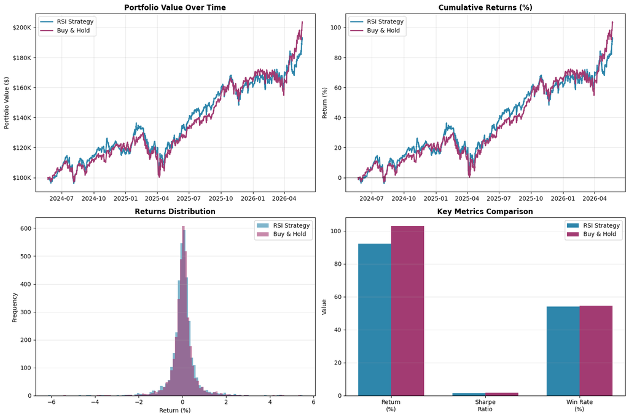

```
Exporting results...

======================================================================
BACKTEST COMPLETE!
======================================================================
```

```python
print("\n" + "="*70)
print("BACKTEST COMPLETE!")
print("="*70)
```

Visualization of all the results

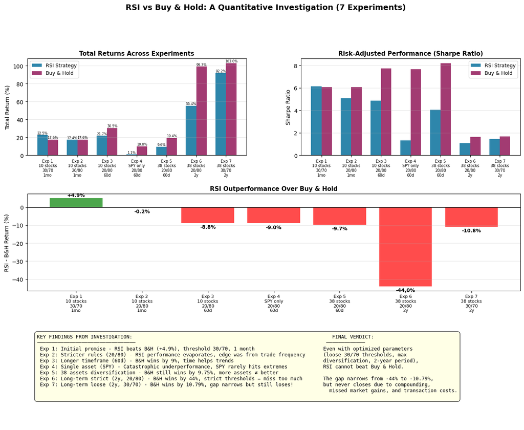

```python
"""
Investigation Journey Summary Chart
Shows all 7 experiments with balanced layout
"""

import matplotlib.pyplot as plt
import numpy as np

# Your actual experimental results
experiments = [
    {'name': 'Exp 1\n10 stocks\n30/70\n1mo', 'rsi': 22.53, 'bh': 17.61, 'sharpe_rsi': 6.14, 'sharpe_bh': 6.05},
    {'name': 'Exp 2\n10 stocks\n20/80\n1mo', 'rsi': 17.36, 'bh': 17.61, 'sharpe_rsi': 5.07, 'sharpe_bh': 6.05},
    {'name': 'Exp 3\n10 stocks\n20/80\n60d', 'rsi': 21.66, 'bh': 30.49, 'sharpe_rsi': 4.85, 'sharpe_bh': 7.71},
    {'name': 'Exp 4\nSPY only\n20/80\n60d', 'rsi': 1.05, 'bh': 10.04, 'sharpe_rsi': 1.31, 'sharpe_bh': 7.64},
    {'name': 'Exp 5\n38 stocks\n20/80\n60d', 'rsi': 9.63, 'bh': 19.38, 'sharpe_rsi': 4.05, 'sharpe_bh': 8.20},
    {'name': 'Exp 6\n38 stocks\n20/80\n2y', 'rsi': 55.39, 'bh': 99.34, 'sharpe_rsi': 1.06, 'sharpe_bh': 1.65},
    {'name': 'Exp 7\n38 stocks\n30/70\n2y', 'rsi': 92.18, 'bh': 102.98, 'sharpe_rsi': 1.46, 'sharpe_bh': 1.68},
]

# Use GridSpec for more flexible layout - 3 rows, 2 cols
from matplotlib.gridspec import GridSpec

fig = plt.figure(figsize=(16, 12))
gs = GridSpec(3, 2, figure=fig, hspace=0.4, wspace=0.25, height_ratios=[1, 1, 1])

x = np.arange(len(experiments))
width = 0.35

# Plot 1: Total Returns Comparison (top-left)
ax1 = fig.add_subplot(gs[0, 0])
rsi_returns = [e['rsi'] for e in experiments]
bh_returns = [e['bh'] for e in experiments]

bars1 = ax1.bar(x - width/2, rsi_returns, width, label='RSI Strategy', color='#2E86AB')
bars2 = ax1.bar(x + width/2, bh_returns, width, label='Buy & Hold', color='#A23B72')

ax1.set_ylabel('Total Return (%)', fontsize=10)
ax1.set_title('Total Returns Across Experiments', fontweight='bold', fontsize=11)
ax1.set_xticks(x)
ax1.set_xticklabels([e['name'] for e in experiments], fontsize=7)
ax1.legend(fontsize=9)
ax1.grid(True, alpha=0.3, axis='y')
ax1.axhline(y=0, color='black', linewidth=0.5)

for bar in bars1 + bars2:
    height = bar.get_height()
    ax1.text(bar.get_x() + bar.get_width()/2., height + 1,
            f'{height:.1f}%', ha='center', fontsize=6)

# Plot 2: Sharpe Ratios (top-right)
ax2 = fig.add_subplot(gs[0, 1])
rsi_sharpes = [e['sharpe_rsi'] for e in experiments]
bh_sharpes = [e['sharpe_bh'] for e in experiments]

bars1 = ax2.bar(x - width/2, rsi_sharpes, width, label='RSI Strategy', color='#2E86AB')
bars2 = ax2.bar(x + width/2, bh_sharpes, width, label='Buy & Hold', color='#A23B72')

ax2.set_ylabel('Sharpe Ratio', fontsize=10)
ax2.set_title('Risk-Adjusted Performance (Sharpe Ratio)', fontweight='bold', fontsize=11)
ax2.set_xticks(x)
ax2.set_xticklabels([e['name'] for e in experiments], fontsize=7)
ax2.legend(fontsize=9)
ax2.grid(True, alpha=0.3, axis='y')

# Plot 3: Outperformance (middle - full width)
ax3 = fig.add_subplot(gs[1, :])
outperformance = [e['rsi'] - e['bh'] for e in experiments]
colors = ['green' if o > 0 else 'red' for o in outperformance]
bars = ax3.bar(x, outperformance, color=colors, alpha=0.7)

ax3.set_ylabel('RSI - B&H Return (%)', fontsize=10)
ax3.set_title('RSI Outperformance Over Buy & Hold', fontweight='bold', fontsize=11)
ax3.set_xticks(x)
ax3.set_xticklabels([e['name'] for e in experiments], fontsize=8)
ax3.axhline(y=0, color='black', linewidth=1)
ax3.grid(True, alpha=0.3, axis='y')

for i, (bar, val) in enumerate(zip(bars, outperformance)):
    height = bar.get_height()
    ax3.text(bar.get_x() + bar.get_width()/2.,
            height + (1 if height > 0 else -3),
            f'{val:+.1f}%', ha='center', fontsize=9, fontweight='bold')

# Plot 4: Findings text (bottom - full width, more rectangular)
ax4 = fig.add_subplot(gs[2, :])
ax4.axis('off')

insights_text = """KEY FINDINGS FROM INVESTIGATION:                                                                   FINAL VERDICT:
─────────────────────────────────                                                                ─────────────
 Exp 1: Initial promise - RSI beats B&H (+4.9%), threshold 30/70, 1 month                       Even with optimized parameters
 Exp 2: Stricter rules (20/80) - RSI performance evaporates, edge was from trade frequency      (loose 30/70 thresholds, max
 Exp 3: Longer timeframe (60d) - B&H wins by 9%, time helps trends                              diversification, 2-year period),
 Exp 4: Single asset (SPY) - Catastrophic underperformance, SPY rarely hits extremes            RSI cannot beat Buy & Hold.
 Exp 5: 38 assets diversification - B&H still wins by 9.75%, more assets ≠ better
 Exp 6: Long-term strict (2y, 20/80) - B&H wins by 44%, strict thresholds = miss too much       The gap narrows from -44% to -10.79%,
 Exp 7: Long-term loose (2y, 30/70) - B&H wins by 10.79%, gap narrows but still loses!          but never closes due to compounding,
                                                                                                  missed market gains, and transaction costs.
"""

ax4.text(0.02, 0.95, insights_text, transform=ax4.transAxes,
        fontsize=9, verticalalignment='top', fontfamily='monospace',
        bbox=dict(boxstyle='round,pad=0.5', facecolor='lightyellow', alpha=0.8))

plt.suptitle('RSI vs Buy & Hold: A Quantitative Investigation (7 Experiments)',
             fontsize=14, fontweight='bold', y=0.995)

plt.savefig('investigation_summary.png', dpi=150, bbox_inches='tight')

plt.show()
```

Final Conclusion

RSI strategies do NOT generate sustainable alpha over Buy & Hold

Key findings:

1. Short-term outperformance (Exp 1) was likely random
2. Performance degrades with longer time periods
3. Diversification doesn't rescue the strategy
4. Buy & Hold wins systematically across configurations

However, RSI may still be useful for:

- Risk reduction (slightly lower drawdowns in some cases)
- Capital preservation in bear markets (not tested here)
- Combination with other signals (e.g., trend filters)

Even if the RSI strategy outperformed Buy & Hold by, say, 5% per year, it would require substantially more time and active management, making it the less preferable strategy.

This validates the Efficient Market Hypothesis at the retail level.